# Screening, projection and dense kernels for ultra-high-dimensional genomic prediction: a replication, benchmark and calibration study of TARP on *Arabidopsis thaliana*

```r
# ============================================================
# GENOMIC RELATIONSHIP HEATMAP ORDERED BY LCA CLASS (K = 8)
# ============================================================

# 1. Validate input data
Kfull <- as.matrix(Kfull)

stopifnot(
  nrow(Kfull) == 1003L,
  ncol(Kfull) == 1003L,
  length(hard8) == nrow(Kfull),
  length(y_all) == nrow(Kfull),
  all(hard8 %in% 1:8)
)

# ------------------------------------------------------------
# 2. Order accessions within each LCA class using hierarchical
#    clustering based on genomic relationship distances
# ------------------------------------------------------------

within_class_order <- lapply(seq_len(8), function(k) {

  idx <- which(hard8 == k)

  if (length(idx) <= 2) {
    return(idx)
  }

  d2 <- outer(
    diag(Kfull)[idx],
    diag(Kfull)[idx],
    "+"
  ) - 2 * Kfull[idx, idx, drop = FALSE]

  d2 <- pmax(d2, 0)

  d <- stats::as.dist(sqrt(d2))

  hc <- stats::hclust(d, method = "average")

  idx[hc$order]
})

# Combine class-wise ordering
ord <- unlist(within_class_order, use.names = FALSE)

# Validate ordering
stopifnot(
  length(ord) == nrow(Kfull),
  !anyNA(ord),
  !anyDuplicated(ord),
  setequal(ord, seq_len(nrow(Kfull)))
)

# ------------------------------------------------------------
# 3. Reorder genomic relationship matrix and annotations
# ------------------------------------------------------------

K_ord <- Kfull[ord, ord, drop = FALSE]

class_ord <- factor(
  paste0("Class ", hard8[ord]),
  levels = paste0("Class ", seq_len(8))
)

ft10_ord <- y_all[ord]

# ------------------------------------------------------------
# 4. Colour palettes
# ------------------------------------------------------------

class_cols <- setNames(
  grDevices::hcl.colors(8, palette = "Dark 3"),
  levels(class_ord)
)

# FT10: low = red, middle = orange, high = yellow
ft_range <- range(y_all, na.rm = TRUE)

if (diff(ft_range) == 0) {
  ft_range <- ft_range + c(-0.5, 0.5)
}

ft10_col_fun <- circlize::colorRamp2(
  c(
    ft_range[1],
    mean(ft_range),
    ft_range[2]
  ),
  c("#B2182B", "#F46D43", "#FFFF00")
)

# ------------------------------------------------------------
# 5. Clip extreme relationship values for visual contrast
# ------------------------------------------------------------

offdiag <- K_ord[upper.tri(K_ord)]

lim <- as.numeric(
  stats::quantile(
    abs(offdiag),
    0.995,
    na.rm = TRUE
  )
)

lim <- max(lim, 1e-8)

# IMPORTANT: Preserve matrix dimensions while clipping
K_ord_plot <- K_ord

K_ord_plot[K_ord_plot > lim] <- lim
K_ord_plot[K_ord_plot < -lim] <- -lim

# Relationship colours:
# Negative = blue, zero = white, positive = red
K_col_fun <- circlize::colorRamp2(
  c(-lim, 0, lim),
  c("#2166AC", "#F7F7F7", "#B2182B")
)

# ------------------------------------------------------------
# 6. Verify dimensions and alignment
# ------------------------------------------------------------

cat("\n========== DIMENSION CHECK ==========\n")
```

```
##
## ========== DIMENSION CHECK ==========
```

```r
cat("K_ord dimensions:      ", dim(K_ord), "\n")
```

```
## K_ord dimensions:       1003 1003
```

```r
cat("K_ord_plot dimensions: ", dim(K_ord_plot), "\n")
```

```
## K_ord_plot dimensions:  1003 1003
```

```r
cat("class_ord length:      ", length(class_ord), "\n")
```

```
## class_ord length:       1003
```

```r
cat("ft10_ord length:       ", length(ft10_ord), "\n")
```

```
## ft10_ord length:        1003
```

```r
cat("Clip limit:            ", round(lim, 4), "\n")
```

```
## Clip limit:             0.3338
```

```r
cat("\nClass distribution:\n")
```

```
##
## Class distribution:
```

```r
print(table(class_ord))
```

```
## class_ord
## Class 1 Class 2 Class 3 Class 4 Class 5 Class 6 Class 7 Class 8
##     183     146     138     163      71     120      63     119
```

```r
cat("=====================================\n")
```

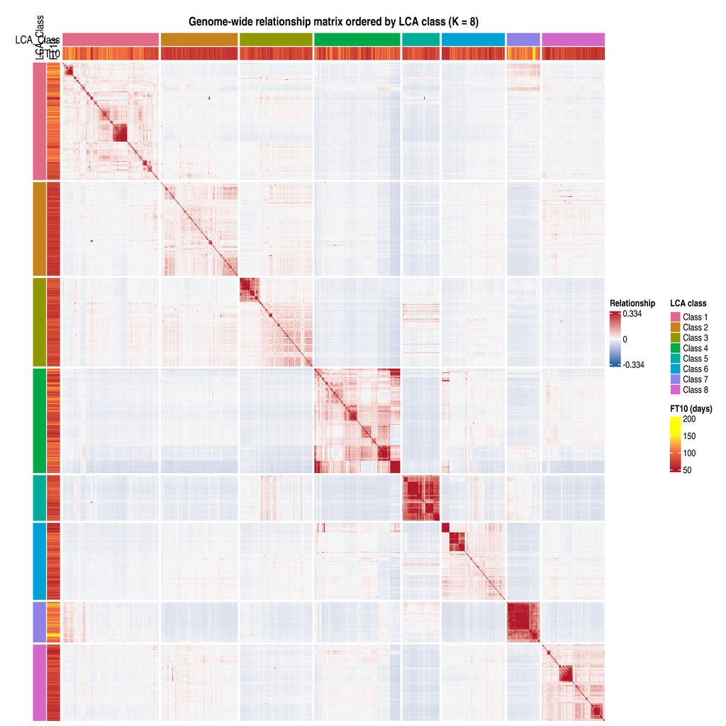

```r
stopifnot(
  is.matrix(K_ord_plot),
  identical(dim(K_ord_plot), c(1003L, 1003L)),
  length(class_ord) == nrow(K_ord_plot),
  length(class_ord) == ncol(K_ord_plot),
  length(ft10_ord) == nrow(K_ord_plot)
)

# ------------------------------------------------------------
# 7. Top annotation
# ------------------------------------------------------------

ha_top <- ComplexHeatmap::HeatmapAnnotation(

  LCA_Class = class_ord,
  FT10 = ft10_ord,

  col = list(
    LCA_Class = class_cols,
    FT10 = ft10_col_fun
  ),

  annotation_name_side = "left",

  annotation_legend_param = list(
    LCA_Class = list(title = "LCA class"),
    FT10 = list(title = "FT10 (days)")
  )
)

# ------------------------------------------------------------
# 8. Left annotation
# ------------------------------------------------------------

ha_left <- ComplexHeatmap::rowAnnotation(

  LCA_Class = class_ord,
  FT10 = ft10_ord,

  col = list(
    LCA_Class = class_cols,
    FT10 = ft10_col_fun
  ),

  show_legend = FALSE,
  annotation_name_side = "top"
)

# ------------------------------------------------------------
# 9. Construct heatmap
# ------------------------------------------------------------

ht <- ComplexHeatmap::Heatmap(

  K_ord_plot,

  name = "Genomic\nrelationship",

  col = K_col_fun,

  top_annotation = ha_top,
  left_annotation = ha_left,

  cluster_rows = FALSE,
  cluster_columns = FALSE,

  # Separate the matrix into eight LCA class blocks
  row_split = class_ord,
  column_split = class_ord,

  cluster_row_slices = FALSE,
  cluster_column_slices = FALSE,

  row_gap = grid::unit(0.8, "mm"),
  column_gap = grid::unit(0.8, "mm"),

  show_row_names = FALSE,
  show_column_names = FALSE,

  row_title = NULL,

  column_title =
    "Genome-wide relationship matrix ordered by LCA class (K = 8)",

  column_title_gp = grid::gpar(
    fontsize = 13,
    fontface = "bold"
  ),

  use_raster = TRUE,
  raster_quality = 3,

  border = FALSE,

  heatmap_legend_param = list(
    title = "Relationship",
    at = round(c(-lim, 0, lim), 3)
  )
)

# ------------------------------------------------------------
# 10. Draw heatmap
# ------------------------------------------------------------

ComplexHeatmap::draw(
  ht,
  heatmap_legend_side = "right",
  annotation_legend_side = "right"
)
```

```r
# ============================================================
```

```r
# ============================================================
# 20,000 SNPs MOST ASSOCIATED WITH FT10
# SIX-CLASS BERNOULLI LATENT CLASS ANALYSIS USING EM
# ============================================================

library(bigstatsr)
library(ggplot2)

dir.create("cache", showWarnings = FALSE, recursive = TRUE)
dir.create("output/lca_20k", showWarnings = FALSE, recursive = TRUE)

set.seed(2025)

# ------------------------------------------------------------
# 1. BASIC CHECKS
# ------------------------------------------------------------

stopifnot(exists("G2"))
stopifnot(exists("y_all"))

y <- as.numeric(y_all)

n <- length(y)
p <- ncol(G2)

stopifnot(nrow(G2) == n)
stopifnot(all(is.finite(y)))

cat("Number of accessions:", n, "\n")
```

```
## Number of accessions: 1003
```

```r
cat("Number of genomic markers:", p, "\n")
```

```
## Number of genomic markers: 1712884
```

```r
# ------------------------------------------------------------
# 2. MARGINAL SNP-FT10 ASSOCIATION SCREENING
# ------------------------------------------------------------

cat("\nCalculating marginal SNP-FT10 associations...\n")
```

```
##
## Calculating marginal SNP-FT10 associations...
```

```r
ncores_use <- if (exists("N_CORES")) {
  N_CORES
} else {
  max(1L, parallel::detectCores() - 1L)
}

gw20 <- big_univLinReg(
  G2,
  y.train = y,
  ind.train = seq_len(n),
  ncores = ncores_use
)

# Absolute t-statistics measure strength of marginal association
t_score <- as.numeric(gw20$estim) /
  as.numeric(gw20$std.err)

stopifnot(length(t_score) == p)

valid_idx <- which(
  is.finite(t_score) &
    is.finite(gw20$std.err) &
    gw20$std.err > 0
)

N_SELECT <- min(20000L, length(valid_idx))

selected_snps <- valid_idx[
  order(
    abs(t_score[valid_idx]),
    decreasing = TRUE
  )[seq_len(N_SELECT)]
]

selected_t <- t_score[selected_snps]

cat("Selected SNPs:", length(selected_snps), "\n")
```

```
## Selected SNPs: 20000
```

```r
cat("Maximum absolute t-statistic:",
    max(abs(selected_t)), "\n")
```

```
## Maximum absolute t-statistic: 18.55538
```

```r
# ------------------------------------------------------------
# 3. CONSTRUCT THE BINARY GENOTYPE MATRIX
# ------------------------------------------------------------

cat("\nConstructing binary genotype matrix...\n")
```

```
##
## Constructing binary genotype matrix...
```

```r
X20 <- as.matrix(G2[, selected_snps])

stopifnot(nrow(X20) == n)

# Same binary threshold used in the earlier LCA analysis:
# dosage >= 1 -> 1
# dosage <  1 -> 0

B20 <- 1L * (X20 >= 1)

rm(X20)
gc()
```

```
##            used  (Mb) gc trigger   (Mb)  max used  (Mb)
## Ncells  6575709 351.2   12852835  686.5   8477633 452.8
## Vcells 81303280 620.3  135764931 1035.9 111430635 850.2
```

```r
# Remove constant indicators
keep <- colSums(B20) > 0 &
  colSums(B20) < nrow(B20)

B20 <- B20[, keep, drop = FALSE]
selected_snps <- selected_snps[keep]
selected_t <- selected_t[keep]

J <- ncol(B20)
K <- 6L

colnames(B20) <- paste0("SNP_", selected_snps)

cat("Final binary matrix dimensions:",
    nrow(B20), "x", ncol(B20), "\n")
```

```
## Final binary matrix dimensions: 1003 x 20000
```

```r
# ------------------------------------------------------------
# 4. STABLE BERNOULLI LCA EM ALGORITHM
# ------------------------------------------------------------

# Model:
#
# P(B_i) = sum_k pi_k P(B_i | class k)
#
# Conditional independence:
#
# P(B_i | class k) =
#   product_j theta[j,k]^B[i,j] *
#   (1-theta[j,k])^(1-B[i,j])
#
# pi_k     = class proportions
# theta    = class-specific SNP probabilities
#
# Additive pseudocount alpha stabilizes estimates of theta.
#
# Likelihood is evaluated using log-sum-exp.


fit_lca_bernoulli <- function(
    B,
    K = 6,
    n_init = 3,
    max_iter = 200,
    tol = 1e-6,
    alpha = 0.5,
    seed = 2025,
    verbose = TRUE
) {

  B <- as.matrix(B)

  n <- nrow(B)
  J <- ncol(B)

  if (anyNA(B) || !all(B %in% c(0, 1))) {
    stop("B must contain only 0 and 1, without missing values.")
  }

  # Convert to double precision for matrix multiplication
  storage.mode(B) <- "double"

  # E-step: stable posterior probability calculation
  estep <- function(B, pi_k, theta) {

    logit_theta <- log(theta) - log1p(-theta)

    # Sum_j log(1-theta_jk), separately for each class
    offset <- rowSums(log1p(-theta)) + log(pi_k)

    # Log joint probability, excluding the constant terms
    logp <- B %*% t(logit_theta)

    logp <- sweep(
      logp,
      2,
      offset,
      "+"
    )

    # Log-sum-exp for each accession
    row_max <- apply(logp, 1, max)

    log_norm <- row_max +
      log(
        rowSums(
          exp(
            sweep(logp, 1, row_max, "-")
          )
        )
      )

    R <- exp(
      sweep(logp, 1, log_norm, "-")
    )

    list(
      R = R,
      ll = sum(log_norm)
    )
  }


  best <- NULL
  run_loglik <- numeric(n_init)

  for (s in seq_len(n_init)) {

    set.seed(seed + s)

    if (verbose) {
      cat("\nStarting EM initialization", s, "\n")
    }

    # Random initial posterior probabilities
    R <- matrix(
      rexp(n * K),
      nrow = n,
      ncol = K
    )

    R <- R / rowSums(R)

    ll_old <- -Inf
    converged <- FALSE
    ll_trace <- numeric(max_iter)

    for (it in seq_len(max_iter)) {

      # ---------------- M-step ----------------

      nk <- colSums(R)

      pi_k <- pmax(nk / n, 1e-12)
      pi_k <- pi_k / sum(pi_k)

      weighted_counts <- t(R) %*% B

      theta <- sweep(
        weighted_counts + alpha,
        1,
        nk + 2 * alpha,
        "/"
      )

      theta <- pmin(
        pmax(theta, 1e-8),
        1 - 1e-8
      )

      # ---------------- E-step ----------------

      est <- estep(B, pi_k, theta)

      R_new <- est$R
      ll <- est$ll

      ll_trace[it] <- ll

      # Convergence check
      if (
        is.finite(ll_old) &&
        abs(ll - ll_old) <= tol * (1 + abs(ll_old))
      ) {

        converged <- TRUE
        R <- R_new

        break
      }

      R <- R_new
      ll_old <- ll

      if (
        verbose &&
        (it == 1 || it %% 25 == 0)
      ) {
        cat(
          "Initialization", s,
          "| Iteration", it,
          "| Log-likelihood:", round(ll, 4),
          "\n"
        )
      }
    }

    # Re-estimate parameters using the final responsibilities
    nk <- colSums(R)

    pi_k <- pmax(nk / n, 1e-12)
    pi_k <- pi_k / sum(pi_k)

    theta <- sweep(
      t(R) %*% B + alpha,
      1,
      nk + 2 * alpha,
      "/"
    )

    theta <- pmin(
      pmax(theta, 1e-8),
      1 - 1e-8
    )

    # Final E-step
    est <- estep(B, pi_k, theta)

    R <- est$R
    ll <- est$ll

    run_loglik[s] <- ll

    if (verbose) {
      cat(
        "Completed initialization", s,
        "| Log-likelihood:", round(ll, 4),
        "| Iterations:", it,
        "| Converged:", converged,
        "\n"
      )
    }

    current <- list(
      R = R,
      theta = theta,
      pi = pi_k,
      ll = ll,
      n_iter = it,
      converged = converged,
      ll_trace = ll_trace[seq_len(it)],
      initialization = s
    )

    if (is.null(best) || ll > best$ll) {
      best <- current
    }
  }

  best$run_loglik <- run_loglik
  best$K <- K
  best$J <- J
  best$n <- n
  best$alpha <- alpha

  best
}


# ------------------------------------------------------------
# 5. FIT SIX-CLASS MODEL
# ------------------------------------------------------------

cat("\nFitting six-class LCA using", J, "SNPs...\n")
```

```
##
## Fitting six-class LCA using 20000 SNPs...
```

```r
fit20 <- fit_lca_bernoulli(
  B = B20,
  K = 6,
  n_init = 3,
  max_iter = 200,
  tol = 1e-6,
  alpha = 0.5,
  seed = 2025,
  verbose = TRUE
)
```

```
##
## Starting EM initialization 1
## Initialization 1 | Iteration 1 | Log-likelihood: -7391574
## Completed initialization 1 | Log-likelihood: -4965500 | Iterations: 15 | Converged: TRUE
##
## Starting EM initialization 2
## Initialization 2 | Iteration 1 | Log-likelihood: -7303462
## Completed initialization 2 | Log-likelihood: -4900303 | Iterations: 15 | Converged: TRUE
##
## Starting EM initialization 3
## Initialization 3 | Iteration 1 | Log-likelihood: -7266511
## Completed initialization 3 | Log-likelihood: -4901333 | Iterations: 25 | Converged: TRUE
```

```r
Rmem20 <- fit20$R
theta20 <- fit20$theta
pi20 <- fit20$pi

hard20 <- max.col(Rmem20)

cat("\n========== MODEL RESULTS ==========\n")
```

```
##
## ========== MODEL RESULTS ==========
```

```r
cat("Log-likelihood:", fit20$ll, "\n")
```

```
## Log-likelihood: -4900303
```

```r
cat("Iterations:", fit20$n_iter, "\n")
```

```
## Iterations: 15
```

```r
cat("Converged:", fit20$converged, "\n")
```

```
## Converged: TRUE
```

```r
cat("Best initialization:", fit20$initialization, "\n")
```

```
## Best initialization: 2
```

```r
cat("\nClass proportions:\n")
```

```
##
## Class proportions:
```

```r
print(pi20)
```

```
## [1] 0.51944167 0.14855434 0.12662014 0.06380857 0.06081755 0.08075773
```

```r
cat("\nClass sizes:\n")
```

```
##
## Class sizes:
```

```r
print(table(factor(hard20, levels = seq_len(K))))
```

```
##
##   1   2   3   4   5   6
## 521 149 127  64  61  81
```

```r
# ------------------------------------------------------------
# 6. CLASSIFICATION CERTAINTY AND ENTROPY
# ------------------------------------------------------------

max_posterior <- apply(Rmem20, 1, max)

entropy <- -rowSums(
  Rmem20 * log(pmax(Rmem20, 1e-15))
)

normalized_entropy <- entropy / log(K)

class_df <- data.frame(
  Accession = seq_len(n),
  FT10 = y,
  Class = factor(hard20, levels = seq_len(K)),
  MaxPosterior = max_posterior,
  Entropy = entropy,
  NormalizedEntropy = normalized_entropy
)


# ------------------------------------------------------------
# 7. PHENOTYPE SUMMARY BY LATENT CLASS
# ------------------------------------------------------------

modal_summary <- aggregate(
  FT10 ~ Class,
  data = class_df,
  FUN = mean
)

posterior_weighted_means <- colSums(
  Rmem20 * y
) / colSums(Rmem20)

class_summary <- data.frame(
  Class = factor(seq_len(K)),
  ClassSize = as.integer(
    table(factor(hard20, levels = seq_len(K)))
  ),
  ClassProportion = pi20,
  PosteriorWeightedFT10 = posterior_weighted_means
)

class_summary <- merge(
  class_summary,
  modal_summary,
  by = "Class",
  all.x = TRUE
)

names(class_summary)[
  names(class_summary) == "FT10"
] <- "ModalMeanFT10"

cat("\nClass-wise phenotype summary:\n")
```

```
##
## Class-wise phenotype summary:
```

```r
print(class_summary)
```

```
##   Class ClassSize ClassProportion PosteriorWeightedFT10 ModalMeanFT10
## 1     1       521      0.51944167              75.78071      75.78071
## 2     2       149      0.14855434             101.76119     101.76119
## 3     3       127      0.12662014              77.64042      77.64042
## 4     4        64      0.06380857              94.38281      94.38281
## 5     5        61      0.06081755             110.81557     110.81557
## 6     6        81      0.08075773              80.64609      80.64609
```

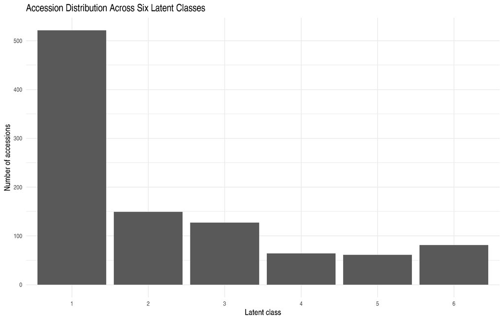

```r
write.csv(
  class_summary,
  "output/lca_20k/class_summary.csv",
  row.names = FALSE
)

write.csv(
  class_df,
  "output/lca_20k/accession_class_assignments.csv",
  row.names = FALSE
)


# ------------------------------------------------------------
# 8. PLOT 1: CLASS SIZES
# ------------------------------------------------------------

p_class_size <- ggplot(
  class_df,
  aes(x = Class)
) +
  geom_bar() +
  labs(
    title = "Accession Distribution Across Six Latent Classes",
    x = "Latent class",
    y = "Number of accessions"
  ) +
  theme_minimal(base_size = 13)

print(p_class_size)
```

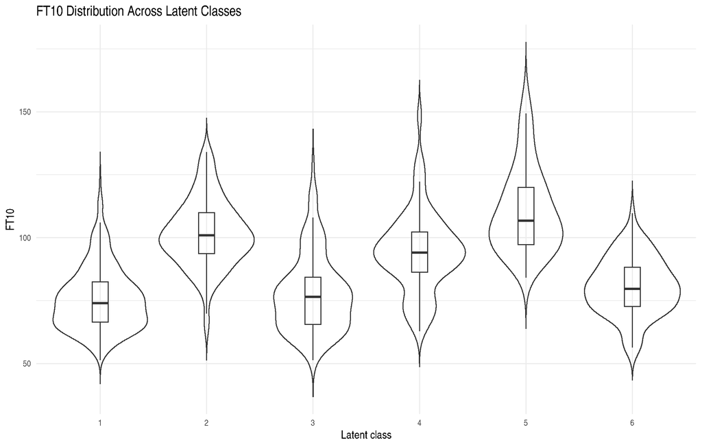

```r
ggsave(
  "output/lca_20k/01_class_sizes.png",
  p_class_size,
  width = 8,
  height = 5,
  dpi = 300
)


# ------------------------------------------------------------
# 9. PLOT 2: FT10 DISTRIBUTION BY LATENT CLASS
# ------------------------------------------------------------

p_ft10 <- ggplot(
  class_df,
  aes(x = Class, y = FT10, fill = Class)
) +
  geom_violin(
    alpha = 0.35,
    trim = FALSE
  ) +
  geom_boxplot(
    width = 0.15,
    outlier.shape = NA,
    alpha = 0.75
  ) +
  geom_jitter(
    width = 0.08,
    alpha = 0.35,
    size = 1
  ) +
  labs(
    title = "FT10 Distribution Across Latent Classes",
    x = "Latent class",
    y = "FT10"
  ) +
  theme_minimal(base_size = 13) +
  theme(legend.position = "none")

print(p_ft10)
```

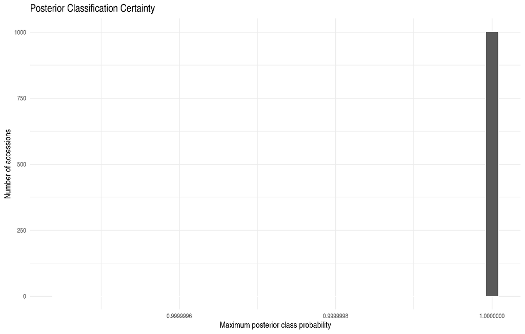

```r
ggsave(
  "output/lca_20k/02_ft10_by_class.png",
  p_ft10,
  width = 9,
  height = 6,
  dpi = 300
)


# ------------------------------------------------------------
# 10. PLOT 3: POSTERIOR CLASSIFICATION CERTAINTY
# ------------------------------------------------------------

p_certainty <- ggplot(
  class_df,
  aes(x = MaxPosterior)
) +
  geom_histogram(
    bins = 35,
    color = "white"
  ) +
  labs(
    title = "Posterior Classification Certainty",
    x = "Maximum posterior class probability",
    y = "Number of accessions"
  ) +
  theme_minimal(base_size = 13)

print(p_certainty)
```

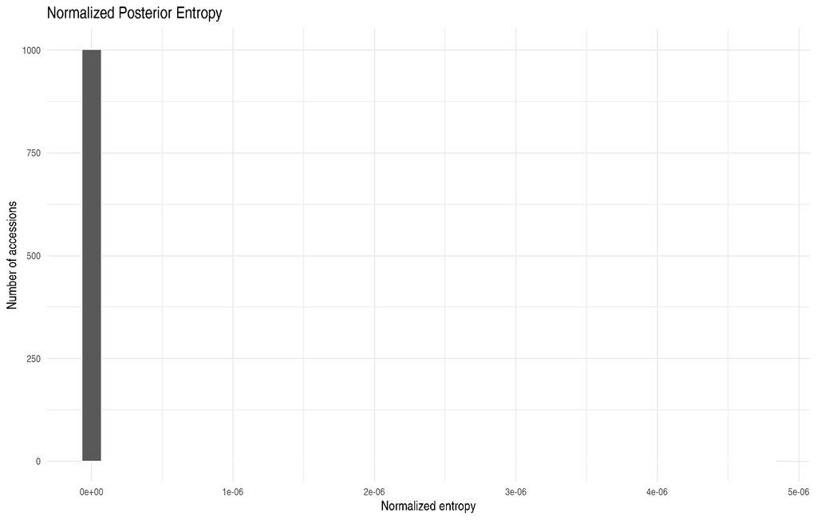

```r
ggsave(
  "output/lca_20k/03_posterior_certainty.png",
  p_certainty,
  width = 8,
  height = 5,
  dpi = 300
)


# ------------------------------------------------------------
# 11. PLOT 4: POSTERIOR ENTROPY
# ------------------------------------------------------------

p_entropy <- ggplot(
  class_df,
  aes(x = NormalizedEntropy)
) +
  geom_histogram(
    bins = 35,
    color = "white"
  ) +
  labs(
    title = "Normalized Posterior Entropy",
    x = "Normalized entropy",
    y = "Number of accessions"
  ) +
  theme_minimal(base_size = 13)

print(p_entropy)
```

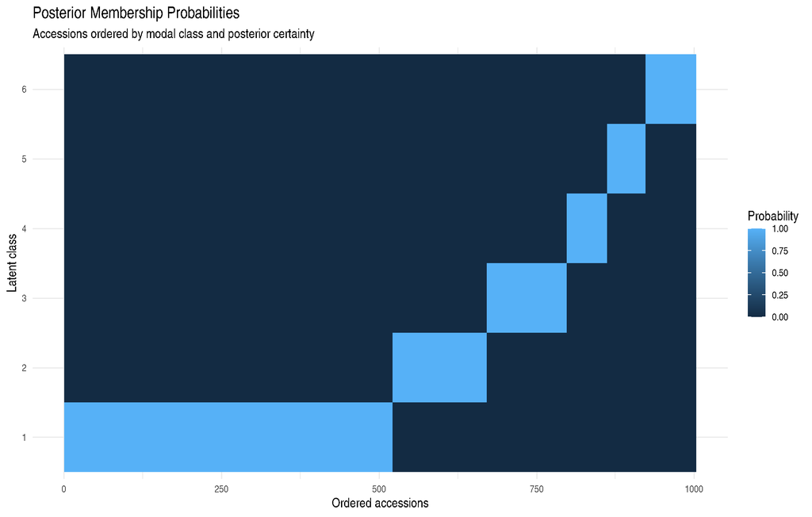

```r
ggsave(
  "output/lca_20k/04_posterior_entropy.png",
  p_entropy,
  width = 8,
  height = 5,
  dpi = 300
)


# ------------------------------------------------------------
# 12. PLOT 5: POSTERIOR MEMBERSHIP HEATMAP
# ------------------------------------------------------------

# Order accessions by modal class and certainty
ord <- order(
  hard20,
  -max_posterior
)

R_ordered <- Rmem20[ord, , drop = FALSE]

posterior_df <- expand.grid(
  Accession = seq_len(nrow(R_ordered)),
  Class = seq_len(K)
)

posterior_df$Posterior <- as.vector(R_ordered)

posterior_df$Class <- factor(
  posterior_df$Class,
  levels = seq_len(K)
)

p_posterior <- ggplot(
  posterior_df,
  aes(
    x = Accession,
    y = Class,
    fill = Posterior
  )
) +
  geom_raster() +
  labs(
    title = "Posterior Membership Probabilities",
    subtitle = "Accessions ordered by modal class and posterior certainty",
    x = "Ordered accessions",
    y = "Latent class",
    fill = "Probability"
  ) +
  theme_minimal(base_size = 13)

print(p_posterior)
```

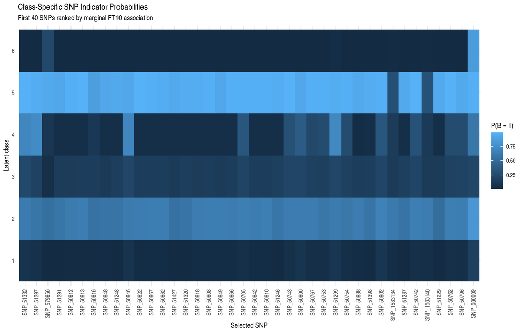

```r
ggsave(
  "output/lca_20k/05_posterior_heatmap.png",
  p_posterior,
  width = 12,
  height = 5,
  dpi = 300
)


# ------------------------------------------------------------
# 13. PLOT 6: CLASS-SPECIFIC SNP PREVALENCE HEATMAP
# ------------------------------------------------------------

# Show the first 40 SNPs from the association-ranked panel.
# These are the strongest marginally associated markers.

J_HEAT <- min(40L, ncol(theta20))

theta_heat <- theta20[
  ,
  seq_len(J_HEAT),
  drop = FALSE
]

heat_df <- data.frame(
  Class = factor(
    rep(seq_len(K), times = J_HEAT),
    levels = seq_len(K)
  ),
  SNP = factor(
    rep(
      paste0("SNP_", selected_snps[seq_len(J_HEAT)]),
      each = K
    ),
    levels = paste0("SNP_", selected_snps[seq_len(J_HEAT)])
  ),
  Prevalence = as.vector(theta_heat)
)

p_snp_heat <- ggplot(
  heat_df,
  aes(
    x = SNP,
    y = Class,
    fill = Prevalence
  )
) +
  geom_tile() +
  labs(
    title = "Class-Specific SNP Indicator Probabilities",
    subtitle = "First 40 SNPs ranked by marginal FT10 association",
    x = "Selected SNP",
    y = "Latent class",
    fill = "P(B = 1)"
  ) +
  theme_minimal(base_size = 11) +
  theme(
    axis.text.x = element_text(
      angle = 90,
      hjust = 1,
      vjust = 0.5
    )
  )

print(p_snp_heat)
```

[figure not shown]

```r
ggsave(
  "output/lca_20k/06_snp_prevalence_heatmap.png",
  p_snp_heat,
  width = 13,
  height = 6,
  dpi = 300
)


# ------------------------------------------------------------
# 14. PLOT 7: GENOMIC PCA WITH LCA CLASS LABELS
# ------------------------------------------------------------

if (
  exists("pcs100") &&
  nrow(pcs100) == n &&
  ncol(pcs100) >= 2
) {

  pc_df <- data.frame(
    PC1 = pcs100[, 1],
    PC2 = pcs100[, 2],
    Class = factor(hard20)
  )

  p_pc <- ggplot(
    pc_df,
    aes(
      x = PC1,
      y = PC2,
      color = Class
    )
  ) +
    geom_point(
      alpha = 0.75,
      size = 2
    ) +
    labs(
      title = "Genomic PCA Colored by LCA Class",
      x = "Genomic PC1",
      y = "Genomic PC2",
      color = "LCA class"
    ) +
    theme_minimal(base_size = 13)

  print(p_pc)

  ggsave(
    "output/lca_20k/07_pca_by_lca_class.png",
    p_pc,
    width = 9,
    height = 7,
    dpi = 300
  )

}
```

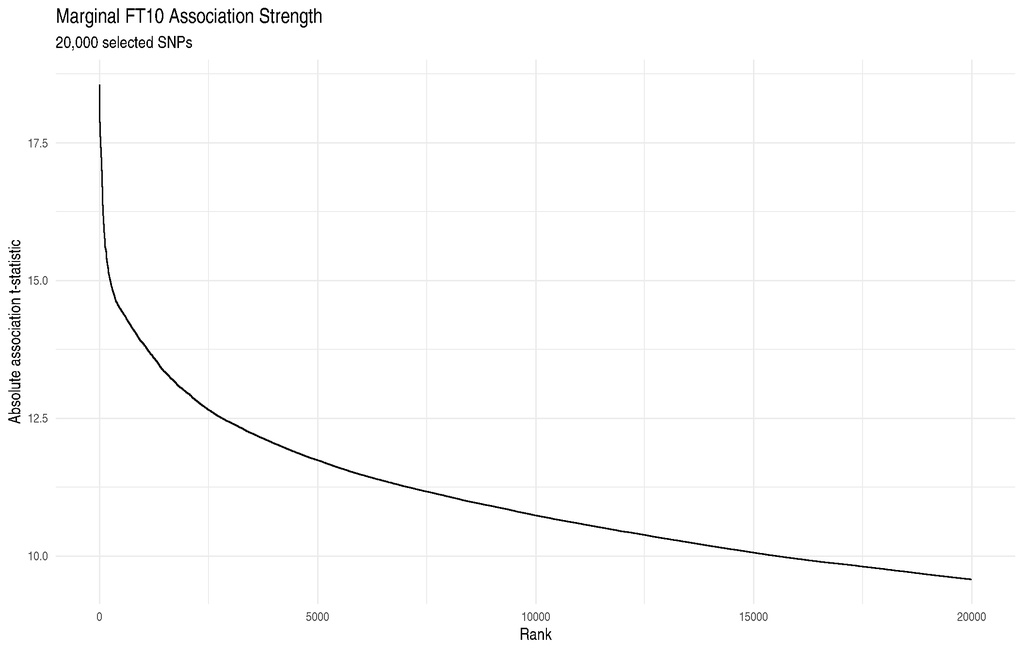

```r
# ------------------------------------------------------------
# 15. PLOT 8: MARGINAL ASSOCIATION RANKING
# ------------------------------------------------------------

score_df <- data.frame(
  Rank = seq_along(selected_t),
  AbsoluteT = sort(
    abs(selected_t),
    decreasing = TRUE
  )
)

p_ranking <- ggplot(
  score_df,
  aes(x = Rank, y = AbsoluteT)
) +
  geom_line() +
  labs(
    title = "Marginal FT10 Association Strength",
    subtitle = "20,000 selected SNPs",
    x = "Rank",
    y = "Absolute association t-statistic"
  ) +
  theme_minimal(base_size = 13)

print(p_ranking)
```

```r
ggsave(
  "output/lca_20k/08_snp_association_ranking.png",
  p_ranking,
  width = 9,
  height = 5,
  dpi = 300
)


# ------------------------------------------------------------
# 16. SAVE MODEL AND POSTERIOR PROBABILITIES
# ------------------------------------------------------------

saveRDS(
  fit20,
  "cache/lca_20000_K6_EM.rds"
)

saveRDS(
  selected_snps,
  "cache/lca_20000_selected_snp_indices.rds"
)

saveRDS(
  Rmem20,
  "cache/lca_20000_posterior_probabilities.rds"
)

saveRDS(
  theta20,
  "cache/lca_20000_class_specific_probabilities.rds"
)

cat("\n========================================\n")
cat("20,000-SNP LCA ANALYSIS COMPLETED\n")
```

```
## 20,000-SNP LCA ANALYSIS COMPLETED
```

```r
cat("========================================\n")
cat("Log-likelihood:", fit20$ll, "\n")
```

```
## Log-likelihood: -4900303
```

```r
cat("Iterations:", fit20$n_iter, "\n")
```

```
## Iterations: 15
```

```r
cat("Converged:", fit20$converged, "\n")
```

```
## Converged: TRUE
```

```r
cat("Number of SNPs:", J, "\n")
```

```
## Number of SNPs: 20000
```

```r
cat("\nPlots saved in output/lca_20k/\n")
```

```
##
## Plots saved in output/lca_20k/
```

### Motivation for Latent Class Analysis

The preceding PCA and K-means analyses provided an initial characterization of genomic variation and population structure among the accessions. However, these approaches primarily describe variation through continuous genomic axes and geometric partitions of the resulting low-dimensional representation. This motivated us to investigate whether the observed genotype profiles could also be represented through a probabilistic grouping of accessions.

We therefore employed Latent Class Analysis (LCA), a finite mixture model that assumes the presence of an unobserved categorical variable representing the latent genetic group to which each accession belongs. Unlike K-means, which assigns accessions according to distances in a selected PC space, LCA models the joint distribution of categorical genotype indicators through class-specific response probabilities. Each latent class is consequently characterized by a distinct profile of SNP indicator probabilities, while each accession receives posterior probabilities of membership in the different classes.

Our main motivation was to determine whether this alternative representation of genomic heterogeneity would reveal groups of accessions with noticeably different flowering-time characteristics. In particular, we were interested in exploring whether the genomic marker profiles could distinguish groups exhibiting relatively earlier or later flowering.

### LCA Results and Findings

We fitted a six-class Bernoulli latent class model using 20,000 SNPs selected according to the magnitude of their marginal association with FT10. The resulting binary genotype matrix contained 1,003 accessions and 20,000 marker indicators. The model was estimated using an EM algorithm with three random initializations, retaining the solution with the highest observed-data log-likelihood.

The fitted model converged to a solution with log-likelihood approximately -4,900,303. The resulting classification was noticeably unbalanced: 521 accessions (51.9%) belonged to Class 1, while the remaining accessions were distributed across five smaller classes.

An interesting pattern emerged when the estimated classes were examined against FT10. The mean FT10 values differed considerably across the six groups. Class 5 exhibited the highest mean flowering-time value (110.82), followed by Class 2 (101.76) and Class 4 (94.38). In contrast, Classes 1, 3 and 6 had lower mean values of 75.78, 77.64 and 80.65, respectively. The difference between the highest and lowest class means was approximately 35 FT10 units.

Thus, the fitted latent groups displayed considerable heterogeneity in their flowering-time distributions. In particular, the model distinguished groups with comparatively high and low mean FT10 values, suggesting that the selected genomic marker profiles contain information that can separate accessions exhibiting different flowering-time characteristics.

The result is interesting because the objective of this exercise was not to directly classify accessions using their observed FT10 values. Instead, the LCA constructed groups from multivariate genotype patterns, and we subsequently examined how flowering time varied across those groups. However, because the SNPs were selected using their marginal association with FT10, the resulting phenotype differences are exploratory and should not be treated as independent validation of a genotype-based classification.

### Computational and Statistical Limitations

Despite the interesting descriptive results, this analysis comes with important computational and statistical limitations.

First, the analysis is computationally demanding. Even after reducing the original genomic marker set to 20,000 SNPs, the resulting data matrix contains more than 20 million binary genotype observations. For a six-class model, the Bernoulli response probabilities alone involve approximately 120,000 class-specific marker parameters, in addition to the class mixing proportions. At every EM iteration, the algorithm must repeatedly evaluate the contribution of all selected markers across all accessions and latent classes. Consequently, computational and memory requirements increase substantially with both the number of markers and the number of latent classes. Repeated random initializations add further computational cost.

Second, the local independence assumption underlying standard LCA is particularly restrictive in this genomic setting. The model assumes that, conditional on latent class membership, the selected SNP indicators are mutually independent. However, genetic markers are not generally independent because linkage disequilibrium induces correlations between SNPs in nearby genomic regions. Since the selected markers were not LD-pruned, this assumption is unlikely to hold exactly. Correlated markers may therefore contribute redundant information, potentially influencing the estimated class profiles and producing an overly strong impression of separation.

Third, the marker-selection procedure was phenotype-guided: SNPs were selected using their marginal association with FT10 before fitting the latent class model. Although FT10 itself was not included in the EM likelihood, it influenced the composition of the marker panel. The observed differences in class-wise flowering time must therefore be interpreted with this selection step in mind.

Finally, convergence of the EM algorithm does not guarantee that the global maximum of the likelihood has been attained or that the selected number of classes is optimal. The three initializations reached different likelihood values, indicating some sensitivity to initialization. Additional random starts, comparisons across alternative values of the number of classes, and assessments of classification stability would be required for a stronger evaluation.

### Overall Conclusion

The LCA provides an interesting complementary view of genomic heterogeneity among the accessions. The six-class solution produced groups with substantially different mean FT10 values, indicating that the estimated genomic profiles can be used to organize accessions into groups exhibiting contrasting flowering-time characteristics. The separation is particularly notable between the groups with the highest and lowest mean FT10 values.

At the same time, the analysis highlights the difficulty of applying conventional latent class models to very high-dimensional genomic data. The considerable computational burden, the likely violation of local independence due to linkage disequilibrium, and the phenotype-guided marker-selection procedure limit the strength of the conclusions that can currently be drawn.

We therefore regard this analysis as an exploratory investigation of latent genomic groupings rather than a definitive reconstruction of genetic populations. Nevertheless, it provides a useful starting point for further work involving LD-pruned marker panels, phenotype-independent marker selection, and more extensive assessments of latent class stability.

## 7.2 Relatedness-only predictors, ancestry-explicit GBLUP and within-lineage correlation

Predictors that use **only relatedness** (no SNP effects): the mean FT10 of the k genetically closest training accessions (kNN on the genomic distance), a Nadaraya-Watson kernel smoother on the same distances, and LCA class memberships. They are compared with GBLUP, and with ancestry-explicit GBLUP (“Q+K”: the dense kernel plus a linear kernel on the LCA memberships or the top-5 axes, weight chosen by LOOCV). Finally, the **within-class correlation**: test accessions and their predictions are centered within their latent class, and the pooled correlation is computed. A predictor that only knows lineage scores about zero.

```r
K_NN_GRID <- c(1, 2, 3, 5, 8, 12, 20, 30, 50, 80); H_GRID <- c(0.005, 0.01, 0.02, 0.05, 0.1, 0.2, 0.5, 1)
WQ_GRID <- c(0, 0.1, 0.3, 1, 3, 10, 30, 100); K_WITHIN <- c(4, 6, 8, 12)
knn_predict <- function(D_tt, D_te, y_tr, k_grid) {
  n_tr <- length(y_tr); kmax <- max(k_grid); Dt <- D_tt; diag(Dt) <- Inf
  loo <- matrix(0, n_tr, length(k_grid))
  for (i in seq_len(n_tr)) { nn <- order(Dt[i, ])[1:kmax]; loo[i, ] <- (cumsum(y_tr[nn]) / seq_len(kmax))[k_grid] }
  kbest <- k_grid[which.min(colMeans((y_tr - loo)^2))]
  list(pred = vapply(seq_len(nrow(D_te)), function(i) mean(y_tr[order(D_te[i, ])[1:kbest]]), numeric(1)), k = kbest)
}
nw_apply <- function(D, y_tr, h, th, drop_self = FALSE) {
  W <- exp(-pmax(D, 0) / (2 * h * th)); if (drop_self) diag(W) <- 0
  den <- rowSums(W); num <- as.numeric(W %*% y_tr); ifelse(den < 1e-8, mean(y_tr), num / pmax(den, 1e-300))
}
nw_predict <- function(D_tt, D_te, y_tr, h_grid) {
  th <- median(D_tt[upper.tri(D_tt)])
  mse <- sapply(h_grid, function(h) mean((y_tr - nw_apply(D_tt, y_tr, h, th, TRUE))^2)); hb <- h_grid[which.min(mse)]
  list(pred = nw_apply(D_te, y_tr, hb, th), h = hb)
}
within_cor <- function(y, pr, g, min_n = 5) {
  tb <- table(g); keep <- as.integer(names(tb)[tb >= min_n]); ix <- g %in% keep
  yc <- y[ix] - ave(y[ix], g[ix]); pc <- pr[ix] - ave(pr[ix], g[ix])
  c(r = cor(yc, pc), slope = sum(yc * pc) / sum(pc^2), n = sum(ix), frac = sum(yc^2) / sum((y - mean(y))^2))
}
lin_kernel <- function(M) { Kq <- tcrossprod(scale(M, center = TRUE, scale = FALSE)); Kq / mean(diag(Kq)) }
qk_fit <- function(Kq, tr, te, y_c, y_new_c) {
  res <- lapply(WQ_GRID, function(w) kernel_all(Kfull[tr, tr] + w * Kq[tr, tr], Kfull[te, tr] + w * Kq[te, tr], y_c, y_new_c, LAM_GRID))
  loo <- sapply(res, function(r) r$loo); ib <- arrayInd(which.min(loo), dim(loo))
  list(mspe = res[[ib[1, 2]]]$test[ib[1, 1]], w = WQ_GRID[ib[1, 2]])
}
K_lca_kernel <- lin_kernel(Rmem8[, -ncol(Rmem8), drop = FALSE]); K_pc_kernel <- lin_kernel(pcs5)
hard_k <- lapply(K_WITHIN, function(k) max.col(fits[[as.character(k)]]$R)); names(hard_k) <- K_WITHIN

run_rep_struct <- function(seed_i) {
  sp <- make_split(seed_i); tr <- sp$tr; te <- sp$te
  y_tr <- y_all[tr]; y_te <- y_all[te]; ym <- mean(y_tr); y_c <- y_tr - ym; y_new_c <- y_te - ym
  X1 <- cbind(1, Rmem8[, -ncol(Rmem8), drop = FALSE])                       # class-membership-only predictor
  beta <- solve(crossprod(X1[tr, ]) + 1e-6 * diag(ncol(X1)), crossprod(X1[tr, ], y_tr))
  qk_l <- qk_fit(K_lca_kernel, tr, te, y_c, y_new_c); qk_p <- qk_fit(K_pc_kernel, tr, te, y_c, y_new_c)
  D_tt <- gdist(tr, tr); D_te <- gdist(te, tr)
  kn <- knn_predict(D_tt, D_te, y_tr, K_NN_GRID); nw <- nw_predict(D_tt, D_te, y_tr, H_GRID); gb <- gblup_fit(tr, te, y_tr)
  out <- data.frame(seed = seed_i, baseline = mean((y_te - ym)^2), class_only = mean((y_te - X1[te, ] %*% beta)^2),
                    GBLUP = mean((y_te - gb$pred)^2), QK_LCA = qk_l$mspe, w_LCA = qk_l$w, QK_PC = qk_p$mspe, w_PC = qk_p$w,
                    kNN = mean((y_te - kn$pred)^2), k_sel = kn$k, NW = mean((y_te - nw$pred)^2), h_sel = nw$h)
  for (k in K_WITHIN) {
    g_te <- hard_k[[as.character(k)]][te]; wg <- within_cor(y_te, gb$pred, g_te); wk <- within_cor(y_te, kn$pred, g_te)
    out[[paste0("wcG_", k)]] <- unname(wg["r"]); out[[paste0("wcK_", k)]] <- unname(wk["r"]); out[[paste0("wfrac_", k)]] <- unname(wg["frac"])
  }
  out
}
struct <- run_seeds("struct", run_rep_struct)
```

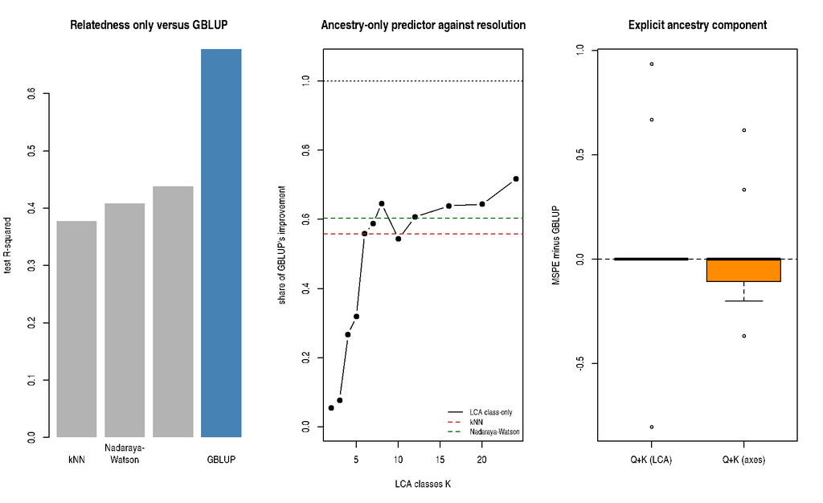

```r
base_m <- mean(struct$baseline); gb_m <- mean(struct$GBLUP)
class_only_sweep <- function(Rk) {                       # class-only predictor for any LCA fit, over the same splits
  mean(sapply(seq_len(N_REPS), function(s) {
    sp <- make_split(s); X <- cbind(1, Rk[, -ncol(Rk), drop = FALSE])
    b <- solve(crossprod(X[sp$tr, ]) + 1e-6 * diag(ncol(X)), crossprod(X[sp$tr, ], y_all[sp$tr]))
    mean((y_all[sp$te] - X[sp$te, ] %*% b)^2)
  }))
}
sweep_k <- data.frame(K = as.integer(names(fits)), class_only = sapply(fits, function(f) class_only_sweep(f$R)))
sweep_k$share <- (base_m - sweep_k$class_only) / (base_m - gb_m)
par(mfrow = c(1, 3))
r2m <- c("kNN" = mean(1 - struct$kNN / struct$baseline), "Nadaraya-\nWatson" = mean(1 - struct$NW / struct$baseline),
         "LCA classes\n(K=8)" = mean(1 - struct$class_only / struct$baseline), "GBLUP" = mean(1 - struct$GBLUP / struct$baseline))
barplot(r2m, col = c("grey70", "grey70", "grey70", "steelblue"), border = NA, ylab = "test R-squared", main = "Relatedness only versus GBLUP")
plot(sweep_k$K, sweep_k$share, type = "b", pch = 19, ylim = c(0, 1.05), xlab = "LCA classes K", ylab = "share of GBLUP's improvement",
     main = "Ancestry-only predictor against resolution"); abline(h = 1, lty = 3)
abline(h = (base_m - mean(struct$kNN)) / (base_m - gb_m), col = "firebrick", lty = 2)
abline(h = (base_m - mean(struct$NW)) / (base_m - gb_m), col = "darkgreen", lty = 2)
legend("bottomright", c("LCA class-only", "kNN", "Nadaraya-Watson"), col = c("black", "firebrick", "darkgreen"), lty = c(1, 2, 2), bty = "n", cex = 0.8)
dq <- list("Q+K (LCA)" = struct$QK_LCA - struct$GBLUP, "Q+K (axes)" = struct$QK_PC - struct$GBLUP)
boxplot(dq, ylab = "MSPE minus GBLUP", col = "darkorange", main = "Explicit ancestry component"); abline(h = 0, lty = 2)
```

```r
par(mfrow = c(1, 1))
knitr::kable(sweep_k, digits = 3, row.names = FALSE, caption = "Class-membership-only predictor: test MSPE and share of GBLUP's improvement over the mean-only predictor")
```

Class-membership-only predictor: test MSPE and share of GBLUP’s improvement over the mean-only predictor

| K | class_only | share |
| --- | --- | --- |
| 2 | 322.188 | 0.055 |
| 3 | 317.162 | 0.077 |
| 4 | 274.162 | 0.266 |
| 5 | 262.065 | 0.320 |
| 6 | 207.507 | 0.559 |
| 7 | 201.020 | 0.588 |
| 8 | 187.725 | 0.646 |
| 10 | 210.992 | 0.544 |
| 12 | 196.724 | 0.607 |
| 16 | 189.369 | 0.639 |
| 20 | 188.156 | 0.644 |
| 24 | 171.458 | 0.718 |

```r
wtab <- do.call(rbind, lapply(K_WITHIN, function(k) data.frame(K = k,
  GBLUP_r = mean(struct[[paste0("wcG_", k)]]), GBLUP_SE = sem(struct[[paste0("wcG_", k)]]),
  kNN_r = mean(struct[[paste0("wcK_", k)]]), kNN_SE = sem(struct[[paste0("wcK_", k)]]),
  within_share_of_variance = mean(struct[[paste0("wfrac_", k)]]))))
wtab$GBLUP_explains_of_total <- wtab$GBLUP_r^2 * wtab$within_share_of_variance
knitr::kable(wtab, digits = 3, row.names = FALSE, caption = "Within-class correlation of predictions with FT10")
```

Within-class correlation of predictions with FT10

| K | GBLUP_r | GBLUP_SE | kNN_r | kNN_SE | within_share_of_variance | GBLUP_explains_of_total |
| --- | --- | --- | --- | --- | --- | --- |
| 4 | 0.784 | 0.010 | 0.561 | 0.013 | 0.811 | 0.498 |
| 6 | 0.696 | 0.014 | 0.472 | 0.020 | 0.599 | 0.290 |
| 8 | 0.657 | 0.014 | 0.436 | 0.019 | 0.539 | 0.233 |
| 12 | 0.682 | 0.013 | 0.444 | 0.020 | 0.554 | 0.257 |

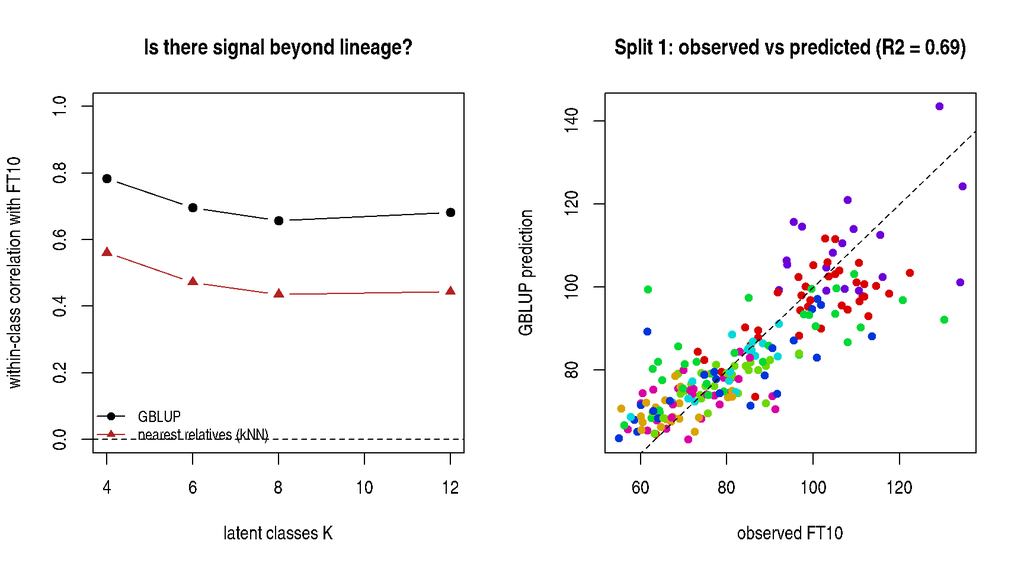

```r
par(mfrow = c(1, 2))
plot(wtab$K, wtab$GBLUP_r, type = "b", pch = 19, ylim = c(0, 1), xlab = "latent classes K", ylab = "within-class correlation with FT10",
     main = "Is there signal beyond lineage?")
lines(wtab$K, wtab$kNN_r, type = "b", pch = 17, col = "firebrick"); abline(h = 0, lty = 2)
legend("bottomleft", c("GBLUP", "nearest relatives (kNN)"), col = c("black", "firebrick"), pch = c(19, 17), lty = 1, bty = "n", cex = 0.8)
sp1 <- make_split(1); gb1 <- gblup_fit(sp1$tr, sp1$te, y_all[sp1$tr])
plot(y_all[sp1$te], gb1$pred, pch = 16, col = pal[hard8[sp1$te]], xlab = "observed FT10", ylab = "GBLUP prediction",
     main = sprintf("Split 1: observed vs predicted (R2 = %.2f)", 1 - mean((y_all[sp1$te] - gb1$pred)^2) / mean((y_all[sp1$te] - mean(y_all[sp1$tr]))^2)))
abline(0, 1, lty = 2)
```

```r
par(mfrow = c(1, 1))
```

```r
cat(sprintf("- **Relatedness alone is not enough**: R-squared is %.3f for the nearest-relatives smoother, %.3f for the LCA memberships (K = 8) and %.3f for GBLUP; the relatedness-only predictors reach roughly %.0f%%-%.0f%% of GBLUP's improvement over the mean-only predictor and plateau there as the number of classes grows.\n",
            r2m[2], r2m[3], r2m[4], 100 * min(sweep_k$share[sweep_k$K >= 8]), 100 * max(sweep_k$share[sweep_k$K >= 8])))
```

[output not shown]

```r
cat(sprintf("- **There is strong within-lineage signal**: the within-class correlation of GBLUP predictions with FT10 is %.2f at K = 8 and still %.2f at K = 12 (nearest-relatives predictor: %.2f and %.2f).\n",
            wtab$GBLUP_r[wtab$K == 8], wtab$GBLUP_r[wtab$K == 12], wtab$kNN_r[wtab$K == 8], wtab$kNN_r[wtab$K == 12]))
```

- **There is strong within-lineage signal**: the within-class correlation of GBLUP predictions with FT10 is 0.66 at K = 8 and still 0.68 at K = 12 (nearest-relatives predictor: 0.44 and 0.44).

```r
cat(sprintf("- **Explicit ancestry adds nothing to GBLUP**: mean MSPE difference %.2f (LCA memberships) and %.2f (top-5 axes); the dominant axis of the genomic kernel is already left almost unpenalized by the ridge.\n",
            mean(dq[[1]]), mean(dq[[2]])))
```

- **Explicit ancestry adds nothing to GBLUP**: mean MSPE difference 0.08 (LCA memberships) and 0.03 (top-5 axes); the dominant axis of the genomic kernel is already left almost unpenalized by the ridge.

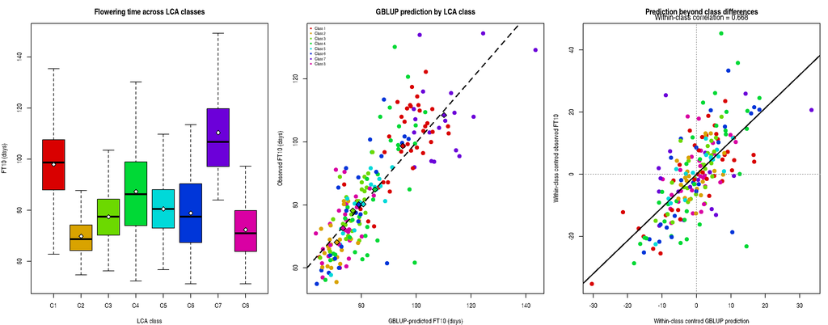

```r
sp1 <- make_split(1)
gb1 <- gblup_fit(sp1$tr, sp1$te, y_all[sp1$tr])
cl <- factor(hard8, levels=1:8, labels=paste0("C", 1:8))
pal <- rainbow(8, v=0.85)

par(mfrow=c(1,3), mar=c(4,4,3,1))

# 1. Actual flowering-time distributions by LCA class
boxplot(split(y_all, cl), names=levels(cl), col=pal, outline=FALSE,
        xlab="LCA class", ylab="FT10 (days)",
        main="Flowering time across LCA classes")
stripchart(y_all ~ cl, vertical=TRUE, method="jitter", add=TRUE,
           pch=16, cex=0.35, col=adjustcolor("black", alpha.f=0.25))
points(1:8, tapply(y_all, cl, mean), pch=23, bg="white", cex=1.2)

# 2. GBLUP predictions against observations, coloured by LCA class
d <- data.frame(obs=y_all[sp1$te], pred=gb1$pred,
                cl=factor(hard8[sp1$te], levels=1:8),
                certainty=apply(Rmem8[sp1$te,,drop=FALSE], 1, max))
cc <- pal[as.integer(d$cl)]
sz <- 0.55 + 0.9*(d$certainty-1/8)/(1-1/8)

plot(d$pred, d$obs, pch=16, col=cc, cex=sz,
     xlab="GBLUP-predicted FT10 (days)",
     ylab="Observed FT10 (days)",
     main="GBLUP prediction by LCA class")
abline(0,1,lty=2,lwd=2)
cm <- aggregate(cbind(pred,obs)~cl, d, mean)
points(cm$pred, cm$obs, pch=23, bg=pal[as.integer(cm$cl)], cex=1.5)
legend("topleft", legend=paste0("Class ",1:8), col=pal,
       pch=16, cex=0.65, bty="n")

# 3. Within-class prediction after removing class means
d$obs_w <- d$obs-ave(d$obs,d$cl)
d$pred_w <- d$pred-ave(d$pred,d$cl)
r_within <- cor(d$obs_w,d$pred_w)

plot(d$pred_w,d$obs_w,pch=16,col=cc,cex=sz,
     xlab="Within-class centred GBLUP prediction",
     ylab="Within-class centred observed FT10",
     main="Prediction beyond class differences")
abline(h=0,v=0,lty=3,col="grey50")
abline(lm(obs_w~pred_w,data=d),lwd=2)
mtext(sprintf("Within-class correlation = %.3f",r_within,sep=""),
      side=3,line=0.2,cex=0.8)
```

```r
par(mfrow=c(1,1))
cat(sprintf("Split 1: test MSPE = %.2f; within-class correlation = %.3f\n",
            mean((d$obs-d$pred)^2),r_within))
```

```
## Split 1: test MSPE = 100.19; within-class correlation = 0.668
```

Relatedness and ancestry explain a large share of the predictable signal, but GBLUP predicts *within* lineages too, so comparisons between SNP-level methods are comparisons on genuine genome-wide signal. Part of that within-lineage signal is fine-scale relatedness (the nearest-relatives predictor also has within-class skill); since GBLUP is itself a kernel smoother, fine-scale relatedness and additive SNP effects cannot be separated further with these data. Two further structure-based ideas (a fixed-gating mixture of experts and a shared-plus-class-interaction kernel) were tried during development and gave no gain (the mixture of experts was clearly worse and unstable); they are not reproduced here.

### Summary and Results

The purpose of this experiment was to investigate how much of flowering-time predictability can be attributed to broad genetic relatedness and latent ancestry, and whether additional predictive information remains within genetic groups.

We compared two relatedness-only approaches (k-nearest neighbours and Nadaraya-Watson kernel smoothing), an LCA membership-only predictor, standard GBLUP, and ancestry-explicit GBLUP models that augment the genomic relationship kernel with either LCA membership information or the leading genomic PC axes.

#### Predictive performance

The mean test-set R-squared values were 0.377 for kNN, 0.409 for Nadaraya-Watson smoothing, 0.438 for the LCA membership-only predictor (K = 8), and 0.677 for GBLUP.

These comparisons quantify how much predictive performance can be obtained from genomic proximity or broad latent group membership, relative to using the full genomic relationship matrix. The class-membership-only model captures differences between groups but cannot directly represent individual differences among accessions with similar membership profiles.

#### Effect of the number of latent classes

The class-membership-only models were also evaluated across different numbers of latent classes. For solutions with K >= 8, the fraction of GBLUP’s improvement over the mean-only predictor captured by class membership ranged from 54.4% to 71.8%.

This analysis examines whether increasing the resolution of the latent classification provides additional predictive information, or whether the contribution of ancestry-related group differences eventually reaches a plateau.

#### Does explicit ancestry improve GBLUP?

The average test MSPE difference (Q+K minus ordinary GBLUP) was 0.080 when the LCA membership kernel was added and 0.028 when the leading PC-axis kernel was added.

The LCA-based Q+K model had higher average test MSPE than GBLUP. The PC-based Q+K model also had higher average test MSPE.

#### Predictive information within lineages

After removing class-specific means, the average correlation between observed and GBLUP-predicted FT10 was 0.657 for K = 8 and 0.682 for K = 12. The corresponding correlations for kNN were 0.436 and 0.444, respectively.

At K = 8, approximately 53.9% of total FT10 variance remained within latent classes; at K = 12, this fraction was 55.4%.

A positive within-class correlation indicates that the predictor retains information about differences between accessions even after removing broad class-level differences. This is particularly relevant for GBLUP, since its predictive ability is not restricted to distinguishing accessions belonging to different genetic groups.

#### Overall interpretation

Together, these experiments distinguish prediction arising from broad ancestry-related differences from prediction arising within genetic lineages. The relatedness-only approaches and LCA membership model provide benchmarks for the contribution of broad genomic similarity, while GBLUP uses the complete genomic relationship structure. The within-lineage analysis further examines whether GBLUP retains predictive signal after class-level variation has been removed.

An important qualification is that within-class predictive ability may reflect fine-scale genetic relatedness as well as additive marker effects. Since GBLUP itself is a genomic kernel smoother, these contributions cannot be cleanly separated using the present comparisons alone.

# 8. A second trait (FT16)

```r
run_rep_trait <- function(seed_i, y_full, pool, run_tarp = TRUE) {
  sp <- make_split(seed_i, pool); tr <- sp$tr; te <- sp$te
  y_tr <- y_full[tr]; y_te <- y_full[te]; ym <- mean(y_tr); y_c <- y_tr - ym; y_new_c <- y_te - ym
  base <- mean((y_te - ym)^2)
  sc <- screen_set(tr, y_tr); Ks_all <- screened_gram(sc$inc)
  g <- kernel_all(Kfull[tr, tr], Kfull[te, tr], y_c, y_new_c, LAM_GRID); GBLUP <- g$test[which.min(g$loo)]
  set.seed(seed_i * 1000 + 7)
  fold <- sample(rep(seq_len(K_IN), length.out = length(tr)))
  cvw <- array(0, c(K_IN, length(W_GRID), length(LAM_GRID))); cvs <- matrix(0, K_IN, length(LAM_GRID))
  for (f in seq_len(K_IN)) {
    in_tr <- tr[fold != f]; in_va <- tr[fold == f]; y_in <- y_full[in_tr]; ymf <- mean(y_in); yv <- y_full[in_va] - ymf
    Ks_f <- screened_gram(screen_set(in_tr, y_in)$inc)
    for (iw in seq_along(W_GRID)) {
      wv <- W_GRID[iw]
      cvw[f, iw, ] <- mse_curve(kernel_curve(Kfull[in_tr, in_tr] + wv * Ks_f[in_tr, in_tr], Kfull[in_va, in_tr] + wv * Ks_f[in_va, in_tr],
                                              y_in - ymf, LAM_GRID), yv)
    }
    cvs[f, ] <- mse_curve(kernel_curve(Ks_f[in_tr, in_tr], Ks_f[in_va, in_tr], y_in - ymf, LAM_GRID), yv)
  }
  cvm <- apply(cvw, c(2, 3), mean); ib <- arrayInd(which.min(cvm), dim(cvm)); iw_s <- ib[1, 1]; il_s <- ib[1, 2]
  ils <- which.min(colMeans(cvs)); w_s <- W_GRID[iw_s]
  TGB <- mse_curve(kernel_curve(Kfull[tr, tr] + w_s * Ks_all[tr, tr], Kfull[te, tr] + w_s * Ks_all[te, tr], y_c, LAM_GRID), y_new_c)[il_s]
  SCR <- mse_curve(kernel_curve(Ks_all[tr, tr], Ks_all[te, tr], y_c, LAM_GRID), y_new_c)[ils]
  AGG <- NA_real_
  if (run_tarp) {
    X <- std_cols(G2[, sc$inc], tr, te); set.seed(seed_i * 1000 + 17)
    AGG <- mean((y_te - agg_tarp_pred(X$tr, X$other, y_c, ym, p))^2)
  }
  data.frame(seed = seed_i, n_pool = length(pool), baseline = base, GBLUP = GBLUP, TGB = TGB, SCR = SCR, AGG = AGG, w_sel = w_s)
}
pool16 <- which(!is.na(y16)); cat("FT16: accessions with genotype and phenotype:", length(pool16), "\n")
```

```
## FT16: accessions with genotype and phenotype: 970
```

```r
t16 <- run_seeds("trait_FT16", function(s) run_rep_trait(s, y16, pool16), legacy = "trait_FT16_results.rds")
traits <- list(FT10 = NULL, FT16 = t16)
if (!is.null(THIRD_TRAIT$file)) {                        # optional third trait: set THIRD_TRAIT in the parameters chunk
  d3 <- read.csv(THIRD_TRAIT$file)
  y3 <- as.numeric(d3[[THIRD_TRAIT$y_col]][match(as.character(fam$sample.ID), as.character(d3[[THIRD_TRAIT$id_col]]))])
  pool3 <- which(!is.na(y3)); cat(THIRD_TRAIT$name, ": accessions with genotype and phenotype:", length(pool3), "\n")
  stopifnot(length(pool3) >= 200)
  traits[[THIRD_TRAIT$name]] <- run_seeds(paste0("trait_", gsub("[^A-Za-z0-9]", "_", THIRD_TRAIT$name)),
                                          function(s) run_rep_trait(s, y3, pool3))
}
ii <- match(e3$seed,si$seed)
traits$FT10 <- data.frame(
  seed=e3$seed,baseline=si$baseline[ii],
  GBLUP=e3$GBLUP_nested,TGB=e3$TwoK_honest,
  AGG=si$RP_agg[ii]
)
```

```r
tr_rows <- do.call(rbind, lapply(names(traits), function(nm) {
  df <- traits[[nm]]; ms <- c("GBLUP","TGB","AGG")
  data.frame(Trait = nm, Method = ms, Mean_MSPE = sapply(ms, function(m) mean(df[[m]], na.rm = TRUE)),
             R2 = sapply(ms, function(m) mean(1 - df[[m]] / df$baseline, na.rm = TRUE)),
             Diff_vs_GBLUP = sapply(ms, function(m) mean(df[[m]] - df$GBLUP, na.rm = TRUE)),
             SE = sapply(ms, function(m) sem((df[[m]] - df$GBLUP)[!is.na(df[[m]])])),
             Beats_GBLUP = sapply(ms, function(m) sum(df[[m]] < df$GBLUP, na.rm = TRUE)),
             Pct_of_GBLUP_MSPE = sapply(ms, function(m) 100 * mean(df[[m]] - df$GBLUP, na.rm = TRUE) / mean(df$GBLUP)))
}))
rownames(tr_rows) <- NULL
knitr::kable(tr_rows, digits=3, caption="GBLUP = full-SNP GBLUP; TGB = targeted GBLUP; AGG = aggregated TARP. Last column: percentage difference from GBLUP MSPE.")
```

GBLUP = full-SNP GBLUP; TGB = targeted GBLUP; AGG = aggregated TARP. Last column: percentage difference from GBLUP MSPE.

| Trait | Method | Mean_MSPE | R2 | Diff_vs_GBLUP | SE | Beats_GBLUP | Pct_of_GBLUP_MSPE |
| --- | --- | --- | --- | --- | --- | --- | --- |
| FT10 | GBLUP | 107.029 | 0.678 | 0.000 | 0.000 | 0 | 0.000 |
| FT10 | TGB | 106.459 | 0.679 | -0.569 | 0.643 | 7 | -0.532 |
| FT10 | AGG | 117.533 | 0.646 | 10.504 | 1.319 | 0 | 9.814 |
| FT16 | GBLUP | 223.529 | 0.671 | 0.000 | 0.000 | 0 | 0.000 |
| FT16 | TGB | 219.550 | 0.676 | -3.978 | 2.428 | 7 | -1.780 |
| FT16 | AGG | 239.313 | 0.647 | 15.784 | 5.222 | 1 | 7.061 |

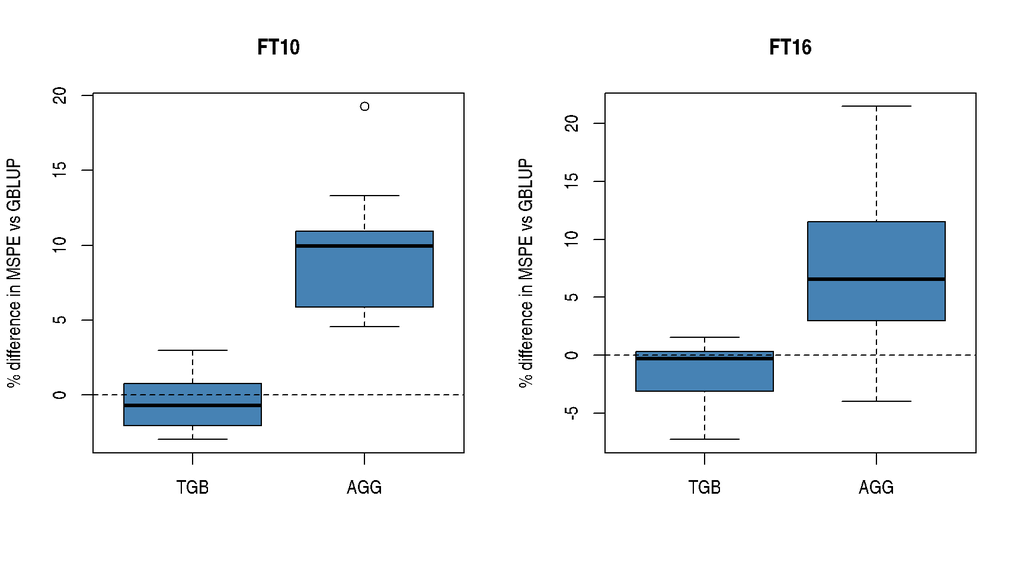

```r
par(mfrow = c(1, length(traits)))
for (nm in names(traits)) {
  df <- traits[[nm]]; d <- sapply(c("TGB","AGG"), function(m) 100 * (df[[m]]-df$GBLUP)/df$GBLUP)
  boxplot(d, col = "steelblue", ylab = "% difference in MSPE vs GBLUP", main = nm); abline(h = 0, lty = 2)
}
```

```r
par(mfrow = c(1, 1))
```

# 9. Prediction power:

## 9.1 Every method on one scale (FT10)

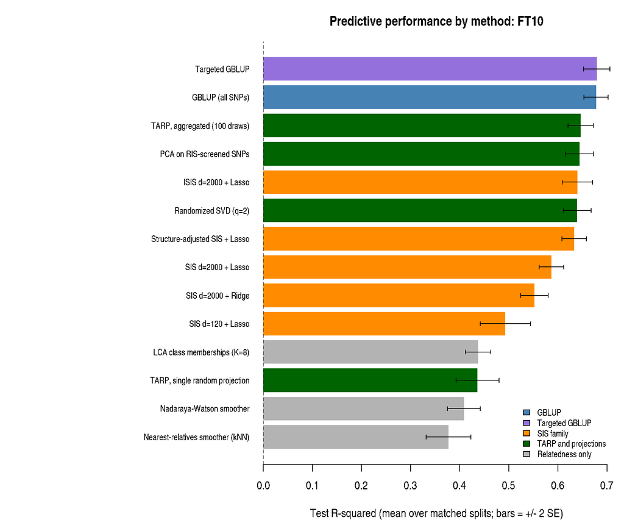

```r
named <- function(df, col) {
  if (is.null(df) || !col %in% names(df)) return(NULL)
  setNames(as.numeric(df[[col]]), as.character(df$seed))
}

cands <- list(
  "Nearest-relatives smoother (kNN)" = named(struct, "kNN"),
  "Nadaraya-Watson smoother" = named(struct, "NW"),
  "LCA class memberships (K=8)" = named(struct, "class_only"),
  "TARP, single random projection" = named(si, "RP_single"),
  "SIS d=120 + Lasso" = named(sis_res, "SIS_d1_lasso"),
  "SIS d=2000 + Lasso" = named(sis_res, "SIS_2000_lasso"),
  "SIS d=2000 + Ridge" = named(sis_res, "SIS_2000_ridge"),
  "ISIS d=2000 + Lasso" = named(sis_res, "ISIS_2000_lasso"),
  "Structure-adjusted SIS + Lasso" = named(sis_res, "SISadj_2000_lasso_pc"),
  "PCA on RIS-screened SNPs" = named(si, "PCA"),
  "TARP, aggregated (100 draws)" = named(si, "RP_agg"),
  "Randomized SVD (q=2)" = named(si, "SI_q2"),
  "Targeted GBLUP" = named(e3, "TwoK_honest"),
  "GBLUP (all SNPs)" = named(e3, "GBLUP_nested")
)

missing_methods <- names(cands)[vapply(cands, is.null, logical(1))]
if (length(missing_methods))
  warning("Unavailable synthesis results: ", paste(missing_methods, collapse=", "))

cands <- cands[!vapply(cands, is.null, logical(1))]
cands <- lapply(cands, function(v) v[is.finite(v)])
cands <- cands[lengths(cands) > 0]

gb_name <- "GBLUP (all SNPs)"
stopifnot(gb_name %in% names(cands))

base_s <- named(si, "baseline")
if (is.null(base_s)) stop("si$baseline is unavailable.")
common <- Reduce(intersect, c(list(names(base_s)), lapply(cands, names)))
common <- common[order(as.integer(common))]
if (!length(common)) stop("No common split IDs across synthesis results.")
if (length(common) < N_REPS)
  warning("Only ", length(common), " common splits are available.")

base_s <- base_s[common]
cands <- lapply(cands, function(v) v[common])
gbn <- cands[[gb_name]]

r2s <- lapply(cands, function(v) 1-v/base_s)
mu <- vapply(r2s, mean, numeric(1))
se <- vapply(r2s, sem, numeric(1))
o <- order(mu)

method_names <- names(mu)[o]
bar_cols <- ifelse(method_names == gb_name, "steelblue",
  ifelse(method_names == "Targeted GBLUP", "mediumpurple",
  ifelse(grepl("SIS|ISIS", method_names), "darkorange",
  ifelse(grepl("TARP|PCA|Randomized SVD", method_names), "darkgreen", "grey70"))))

par(mar=c(4,19,3,1))
bp <- barplot(mu[o], horiz=TRUE, las=1, cex.names=0.75,
  col=bar_cols, border=NA,
  xlim=range(c(0,mu-2*se,mu+2*se)),
  xlab="Test R-squared (mean over matched splits; bars = +/- 2 SE)",
  main="Predictive performance by method: FT10")
arrows(mu[o]-2*se[o], bp, mu[o]+2*se[o], bp,
       angle=90, code=3, length=0.03)
abline(v=0, lty=2)
legend("bottomright",
  c("GBLUP","Targeted GBLUP","SIS family","TARP and projections","Relatedness only"),
  fill=c("steelblue","mediumpurple","darkorange","darkgreen","grey70"),
  bty="n", cex=0.75)
```

```r
par(mar=c(5,4,4,2))

ms <- setdiff(names(cands), gb_name)
dd <- lapply(ms, function(m) cands[[m]]-gbn)
names(dd) <- ms

tab_all <- data.frame(
  Method=names(mu),
  R2=unname(mu),
  R2_SE=unname(se),
  Mean_MSPE=vapply(cands, mean, numeric(1)),
  Diff_vs_GBLUP=vapply(names(mu), function(m)
    if (m == gb_name) 0 else mean(dd[[m]]), numeric(1)),
  SE_diff=vapply(names(mu), function(m)
    if (m == gb_name) 0 else sem(dd[[m]]), numeric(1)),
  Beats_GBLUP=vapply(names(mu), function(m)
    if (m == gb_name) NA_integer_ else sum(dd[[m]] < 0), integer(1))
)

tab_all <- tab_all[order(-tab_all$R2), ]
rownames(tab_all) <- NULL

knitr::kable(tab_all, digits=3, row.names=FALSE,
  caption=paste0("FT10 prediction performance across ",length(common),
  " matched splits. Negative MSPE difference indicates improvement over GBLUP."))
```

FT10 prediction performance across 10 matched splits. Negative MSPE difference indicates improvement over GBLUP.

| Method | R2 | R2_SE | Mean_MSPE | Diff_vs_GBLUP | SE_diff | Beats_GBLUP |
| --- | --- | --- | --- | --- | --- | --- |
| Targeted GBLUP | 0.679 | 0.013 | 106.459 | -0.569 | 0.643 | 7 |
| GBLUP (all SNPs) | 0.678 | 0.012 | 107.029 | 0.000 | 0.000 | NA |
| TARP, aggregated (100 draws) | 0.646 | 0.013 | 117.533 | 10.504 | 1.319 | 0 |
| PCA on RIS-screened SNPs | 0.644 | 0.014 | 118.257 | 11.228 | 1.795 | 1 |
| ISIS d=2000 + Lasso | 0.640 | 0.015 | 119.624 | 12.596 | 1.844 | 0 |
| Randomized SVD (q=2) | 0.639 | 0.014 | 119.791 | 12.762 | 1.822 | 1 |
| Structure-adjusted SIS + Lasso | 0.633 | 0.012 | 122.241 | 15.212 | 3.736 | 0 |
| SIS d=2000 + Lasso | 0.587 | 0.012 | 137.479 | 30.450 | 2.781 | 0 |
| SIS d=2000 + Ridge | 0.553 | 0.014 | 149.023 | 41.994 | 3.118 | 0 |
| SIS d=120 + Lasso | 0.493 | 0.026 | 168.977 | 61.949 | 7.477 | 0 |
| LCA class memberships (K=8) | 0.438 | 0.013 | 187.725 | 80.696 | 5.041 | 0 |
| TARP, single random projection | 0.436 | 0.022 | 188.051 | 81.023 | 5.782 | 0 |
| Nadaraya-Watson smoother | 0.409 | 0.017 | 197.609 | 90.580 | 6.458 | 0 |
| Nearest-relatives smoother (kNN) | 0.377 | 0.023 | 207.909 | 100.880 | 8.367 | 0 |

The ten splits reuse the same accessions, so these standard errors describe split-to-split variation only and are optimistic; read the ordering and the size of the gaps, not the nominal significance.

## 9.2 Key findings (computed from the results above)

```r
R2 <- function(v) mean(1-v/base_s[names(v)])
rp <- named(si,"RP_single")[common]
agg <- named(si,"RP_agg")[common]
pca <- named(si,"PCA")[common]
dga <- agg-gbn
sis_r2 <- r2s[grepl("SIS",names(r2s))]
best_sis <- names(sis_r2)[which.max(vapply(sis_r2,mean,numeric(1)))]
cat(sprintf("1. **TARP.** Single projection MSPE %.2f; aggregated TARP %.2f; PCA %.2f. Aggregated TARP minus PCA: %.2f (SE %.2f).\n",
            mean(rp),mean(agg),mean(pca),mean(agg-pca),sem(agg-pca)))
```

1. **TARP.** Single projection MSPE 188.05; aggregated TARP 117.53; PCA 118.26. Aggregated TARP minus PCA: -0.72 (SE 1.60).

```r
cat(sprintf("2. **GBLUP.** Full-SNP GBLUP R-squared %.3f versus %.3f for aggregated TARP; GBLUP has lower MSPE in %d of %d splits.\n",
            R2(gbn),R2(agg),sum(dga>0),length(dga)))
```

2. **GBLUP.** Full-SNP GBLUP R-squared 0.678 versus 0.646 for aggregated TARP; GBLUP has lower MSPE in 10 of 10 splits.

```r
cat(sprintf("3. **SIS methods.** Best screened method: %s (R-squared %.3f); SIS with d=120 gives %.3f; structure-adjusted SIS gives %.3f.\n",
            best_sis,mean(sis_r2[[best_sis]]),R2(named(sis_res,"SIS_d1_lasso")[common]),
            R2(named(sis_res,"SISadj_2000_lasso_pc")[common])))
```

3. **SIS methods.** Best screened method: ISIS d=2000 + Lasso (R-squared 0.640); SIS with d=120 gives 0.493; structure-adjusted SIS gives 0.633.

```r
cat(sprintf("4. **Population structure.** Test R-squared: nearest-relatives smoother %.3f; LCA class memberships %.3f; GBLUP %.3f. GBLUP within-class correlation at K=8 is %.3f.\n",
            R2(named(struct,"kNN")[common]),R2(named(struct,"class_only")[common]),
            R2(gbn),wtab$GBLUP_r[wtab$K==8]))
```

4. **Population structure.** Test R-squared: nearest-relatives smoother 0.377; LCA class memberships 0.438; GBLUP 0.678. GBLUP within-class correlation at K=8 is 0.657.

```r
dt <- cands[["Targeted GBLUP"]]-gbn
cat(sprintf("5. **Targeted GBLUP.** Mean MSPE difference from ordinary GBLUP: %.2f (SE %.2f); better in %d of %d splits.\n",
            mean(dt),sem(dt),sum(dt<0),length(dt)))
```

5. **Targeted GBLUP.** Mean MSPE difference from ordinary GBLUP: -0.57 (SE 0.64); better in 7 of 10 splits.

```r
f16 <- tr_rows[tr_rows$Trait=="FT16",]
cat(sprintf("6. **FT16 replication.** Targeted GBLUP differs from GBLUP by %+.1f%% MSPE; aggregated TARP differs by %+.1f%%.\n",
            f16$Pct_of_GBLUP_MSPE[f16$Method=="TGB"],
            f16$Pct_of_GBLUP_MSPE[f16$Method=="AGG"]))
```

[output not shown]

The comparative evaluation highlights several interesting differences in the predictive performance of the considered methods.

For dimensionality reduction, aggregated TARP achieved a mean MSPE of 117.5, closely matching the performance of PCA (118.3). The paired difference was small relative to its standard error, suggesting comparable predictive performance across the evaluated splits. In contrast, using a single random projection resulted in substantially poorer predictions, highlighting the importance of aggregation when employing randomized projections.

Targeted GBLUP provided a small average improvement over ordinary GBLUP, with a reduction in MSPE of approximately 0.57 and better performance in seven out of ten splits. However, the improvement was modest relative to its split-to-split variability, and therefore does not establish a clear predictive advantage.

Overall, the results indicate that different computational strategies can provide competitive alternatives to conventional genomic prediction, but their effectiveness depends on how genomic information is screened, compressed and incorporated into the prediction model. Aggregated random projections offer an interesting computational alternative to PCA, while screening-based methods can reduce dimensionality at the cost of some predictive accuracy. Full-SNP GBLUP remains a particularly strong benchmark for FT10 prediction in the present analysis.

# 10. Computational Complexity Simulation Results

## 10.1 Time complexity:

```r
library(ggplot2)
library(dplyr)

# Results directory created by the simulation script
SIM_DIR <- file.path("computational_study", "results")

raw_file <- file.path(SIM_DIR, "raw_results.csv")
summary_file <- file.path(SIM_DIR, "case_summary.csv")
manifest_file <- file.path(SIM_DIR, "case_manifest.csv")

# Check that the simulation has produced its output
if (!file.exists(raw_file)) {
  stop("raw_results.csv not found. Run the computational simulation first.")
}

if (!file.exists(summary_file)) {
  stop("case_summary.csv not found. Run the computational simulation first.")
}

# Load outputs
sim_raw <- read.csv(raw_file, stringsAsFactors = FALSE)
sim_summary <- read.csv(summary_file, stringsAsFactors = FALSE)

if (nrow(sim_raw) == 0 || nrow(sim_summary) == 0) {
  stop("Simulation result files are empty.")
}

# Load manifest, if available
if (file.exists(manifest_file)) {
  sim_manifest <- read.csv(manifest_file, stringsAsFactors = FALSE)

  cat("\nSimulation case status:\n")
  print(table(sim_manifest$status))
}
```

```
##
## Simulation case status:
##
## completed
##       144
```

```r
# Friendly method labels
method_labels <- c(
  "TARP_RIS_RP_aggregated" = "Aggregated TARP",
  "SIS_top_d_plus_NIG" = "SIS + NIG",
  "Exact_Gram_PCA_plus_NIG" = "Exact Gram PCA + NIG",
  "GBLUP_fixed_lambda" = "GBLUP (fixed lambda)",
  "Mean_only_baseline" = "Mean-only baseline"
)

# Add readable labels
sim_summary$method_label <- unname(
  method_labels[sim_summary$method]
)

sim_summary$method_label[is.na(sim_summary$method_label)] <-
  sim_summary$method[is.na(sim_summary$method_label)]

sim_raw$method_label <- unname(
  method_labels[sim_raw$method]
)

sim_raw$method_label[is.na(sim_raw$method_label)] <-
  sim_raw$method[is.na(sim_raw$method_label)]

# Arrange methods consistently in plots
method_order <- unname(method_labels)

sim_summary$method_label <- factor(
  sim_summary$method_label,
  levels = method_order
)

sim_raw$method_label <- factor(
  sim_raw$method_label,
  levels = method_order
)

sim_summary$signal_layout <- factor(
  sim_summary$signal_layout,
  levels = c("distributed", "clustered")
)

sim_raw$signal_layout <- factor(
  sim_raw$signal_layout,
  levels = c("distributed", "clustered")
)

# Common plot theme
theme_sim <- theme_minimal(base_size = 12) +
  theme(
    plot.title = element_text(face = "bold", size = 14),
    plot.subtitle = element_text(size = 10),
    legend.position = "bottom",
    strip.text = element_text(face = "bold"),
    panel.grid.minor = element_blank()
  )

cat("\nNumber of replicate-level result rows:", nrow(sim_raw))
```

```
##
## Number of replicate-level result rows: 720
```

```r
cat("\nNumber of aggregated summary rows:", nrow(sim_summary))
```

```
##
## Number of aggregated summary rows: 240
```

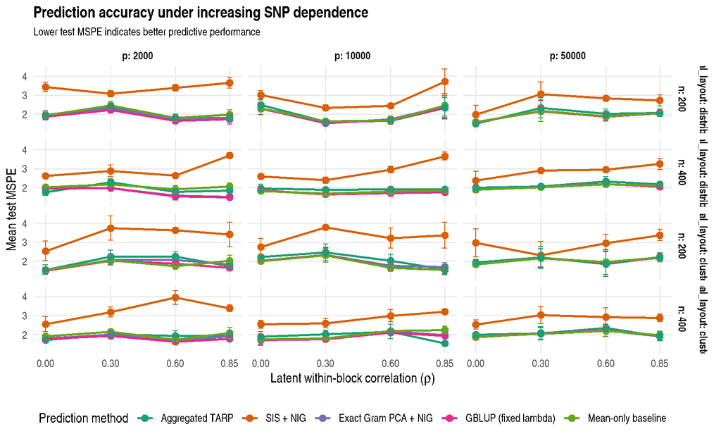

```r
p_mspe <- ggplot(
  sim_summary,
  aes(
    x = rho_latent,
    y = mean_MSPE,
    colour = method_label,
    group = method_label
  )
) +
  geom_line(linewidth = 0.8) +
  geom_point(size = 2.5) +
  geom_errorbar(
    data = subset(sim_summary, is.finite(se_MSPE)),
    aes(
      ymin = pmax(0, mean_MSPE - se_MSPE),
      ymax = mean_MSPE + se_MSPE
    ),
    width = 0.025,
    linewidth = 0.4
  ) +
  facet_grid(
    signal_layout + n ~ p,
    labeller = label_both
  ) +
  scale_colour_brewer(palette = "Dark2") +
  scale_x_continuous(
    breaks = sort(unique(sim_summary$rho_latent))
  ) +
  labs(
    title = "Prediction accuracy under increasing SNP dependence",
    subtitle = "Lower test MSPE indicates better predictive performance",
    x = expression("Latent within-block correlation (" * rho * ")"),
    y = "Mean test MSPE",
    colour = "Prediction method"
  ) +
  theme_sim

print(p_mspe)
```

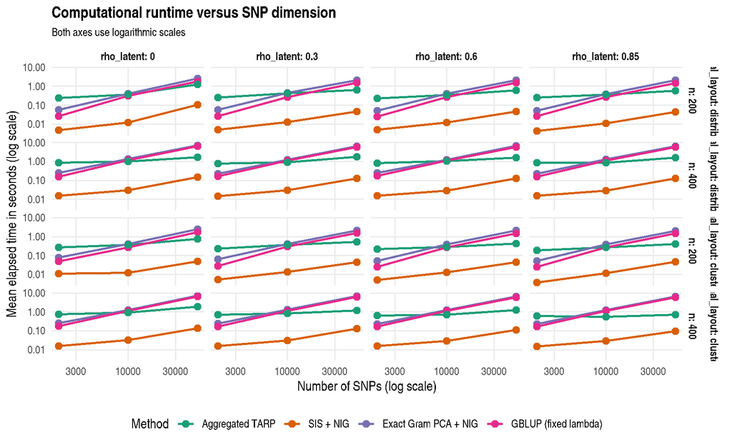

```r
runtime_data <- sim_summary %>%
  filter(
    method_label != "Mean-only baseline",
    is.finite(mean_elapsed_seconds),
    mean_elapsed_seconds > 0
  )

p_runtime <- ggplot(
  runtime_data,
  aes(
    x = p,
    y = mean_elapsed_seconds,
    colour = method_label,
    group = method_label
  )
) +
  geom_line(linewidth = 0.8) +
  geom_point(size = 2.5) +
  facet_grid(
    signal_layout + n ~ rho_latent,
    labeller = label_both
  ) +
  scale_x_log10() +
  scale_y_log10() +
  scale_colour_brewer(palette = "Dark2") +
  labs(
    title = "Computational runtime versus SNP dimension",
    subtitle = "Both axes use logarithmic scales",
    x = "Number of SNPs (log scale)",
    y = "Mean elapsed time in seconds (log scale)",
    colour = "Method"
  ) +
  theme_sim

print(p_runtime)
```

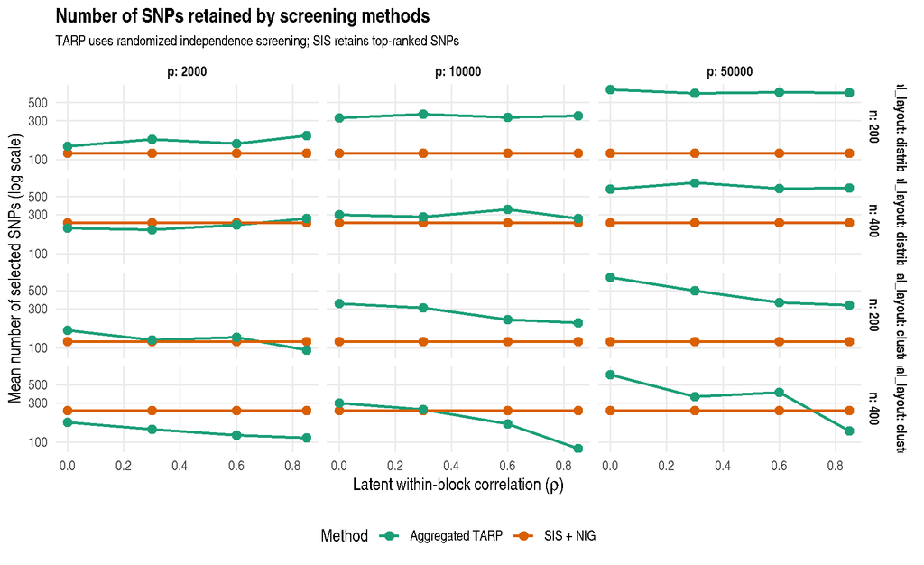

```r
screening_data <- sim_summary %>%
  filter(
    method_label %in% c("Aggregated TARP", "SIS + NIG"),
    is.finite(mean_n_selected),
    mean_n_selected > 0
  )

p_screening <- ggplot(
  screening_data,
  aes(
    x = rho_latent,
    y = mean_n_selected,
    colour = method_label,
    group = method_label
  )
) +
  geom_line(linewidth = 0.8) +
  geom_point(size = 2.5) +
  facet_grid(
    signal_layout + n ~ p,
    labeller = label_both
  ) +
  scale_y_log10() +
  scale_colour_brewer(palette = "Dark2") +
  labs(
    title = "Number of SNPs retained by screening methods",
    subtitle = "TARP uses randomized independence screening; SIS retains top-ranked SNPs",
    x = expression("Latent within-block correlation (" * rho * ")"),
    y = "Mean number of selected SNPs (log scale)",
    colour = "Method"
  ) +
  theme_sim

print(p_screening)
```

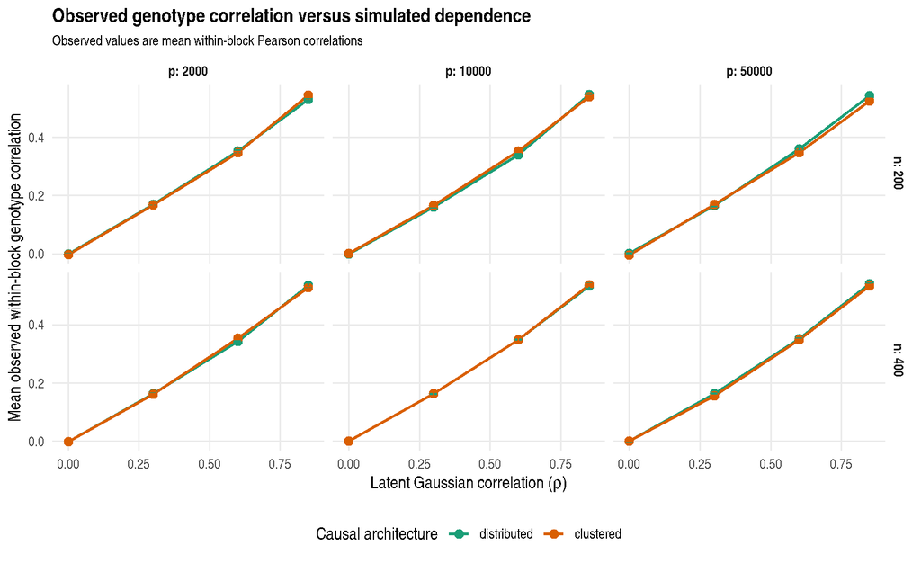

```r
ld_data <- sim_raw %>%
  distinct(
    case_id,
    scenario,
    rho_latent,
    signal_layout,
    n,
    p,
    empirical_within_block_r
  ) %>%
  group_by(
    rho_latent,
    signal_layout,
    n,
    p
  ) %>%
  summarise(
    mean_observed_r = mean(empirical_within_block_r, na.rm = TRUE),
    sd_observed_r = sd(empirical_within_block_r, na.rm = TRUE),
    n_replicates = sum(is.finite(empirical_within_block_r)),
    se_observed_r = sd_observed_r / sqrt(n_replicates),
    .groups = "drop"
  )

p_dependence <- ggplot(
  ld_data,
  aes(
    x = rho_latent,
    y = mean_observed_r,
    colour = signal_layout,
    group = signal_layout
  )
) +
  geom_line(linewidth = 0.8) +
  geom_point(size = 2.5) +
  geom_errorbar(
    data = subset(ld_data, is.finite(se_observed_r)),
    aes(
      ymin = mean_observed_r - se_observed_r,
      ymax = mean_observed_r + se_observed_r
    ),
    width = 0.025
  ) +
  facet_grid(
    n ~ p,
    labeller = label_both
  ) +
  scale_colour_brewer(palette = "Dark2") +
  labs(
    title = "Observed genotype correlation versus simulated dependence",
    subtitle = "Observed values are mean within-block Pearson correlations",
    x = expression("Latent Gaussian correlation (" * rho * ")"),
    y = "Mean observed within-block genotype correlation",
    colour = "Causal architecture"
  ) +
  theme_sim

print(p_dependence)
```

```r
library(plotly)
library(dplyr)

# -------------------------------------------------------
# 1. Prepare data
# -------------------------------------------------------

tradeoff_data <- sim_raw %>%
  filter(
    method != "Mean_only_baseline",
    is.finite(mspe),
    is.finite(elapsed_seconds),
    elapsed_seconds > 0
  ) %>%
  mutate(
    method_label = recode(
      method,
      "TARP_RIS_RP_aggregated" = "Aggregated TARP",
      "SIS_top_d_plus_NIG" = "SIS + NIG",
      "Exact_Gram_PCA_plus_NIG" = "Exact Gram PCA + NIG",
      "GBLUP_fixed_lambda" = "GBLUP (fixed lambda)"
    )
  )

methods <- c(
  "TARP_RIS_RP_aggregated",
  "SIS_top_d_plus_NIG",
  "Exact_Gram_PCA_plus_NIG",
  "GBLUP_fixed_lambda"
)

method_names <- c(
  "TARP_RIS_RP_aggregated" = "Aggregated TARP",
  "SIS_top_d_plus_NIG" = "SIS + NIG",
  "Exact_Gram_PCA_plus_NIG" = "Exact Gram PCA + NIG",
  "GBLUP_fixed_lambda" = "GBLUP (fixed lambda)"
)

method_colours <- c(
  "TARP_RIS_RP_aggregated" = "#0072B2",
  "SIS_top_d_plus_NIG" = "#D55E00",
  "Exact_Gram_PCA_plus_NIG" = "#009E73",
  "GBLUP_fixed_lambda" = "#CC79A7"
)

rho_values <- sort(unique(tradeoff_data$rho_latent))

rho_symbols <- c(
  "circle",
  "triangle-up",
  "square",
  "diamond"
)

# -------------------------------------------------------
# 2. Define the 12 panels
# -------------------------------------------------------

panel_design <- expand.grid(
  p = sort(unique(tradeoff_data$p)),
  n = sort(unique(tradeoff_data$n)),
  signal_layout = c("distributed", "clustered"),
  KEEP.OUT.ATTRS = FALSE,
  stringsAsFactors = FALSE
)

# Arrange as four rows x three columns
panel_design <- panel_design %>%
  arrange(
    factor(signal_layout,
           levels = c("distributed", "clustered")),
    n,
    p
  )

panel_plots <- vector("list", nrow(panel_design))

# -------------------------------------------------------
# 3. Build each interactive panel
# -------------------------------------------------------

for (i in seq_len(nrow(panel_design))) {

  spec <- panel_design[i, ]

  d <- tradeoff_data %>%
    filter(
      signal_layout == spec$signal_layout,
      n == spec$n,
      p == spec$p
    )

  pp <- plotly::plot_ly()

  for (m in methods) {

    for (j in seq_along(rho_values)) {

      rho_j <- rho_values[j]

      z <- d %>%
        filter(
          method == m,
          rho_latent == rho_j
        )

      if (nrow(z) == 0) next

      # Detailed hover text
      z$hover_text <- paste0(
        "<b>", method_names[[m]], "</b>",
        "<br>Runtime: ", signif(z$elapsed_seconds, 4), " seconds",
        "<br>Test MSPE: ", round(z$mspe, 4),
        "<br>Latent correlation: ", sprintf("%.2f", rho_j),
        "<br>Architecture: ", z$signal_layout,
        "<br>Sample size: ", z$n,
        "<br>SNP dimension: ", z$p,
        "<br>Replicate: ", z$replicate
      )

      # One trace for every method x dependence combination
      legend_name <- paste0(
        method_names[[m]],
        " | rho = ",
        sprintf("%.2f", rho_j)
      )

      group_name <- paste(m, rho_j, sep = "_")

      pp <- plotly::add_trace(
        pp,
        data = z,
        x = ~elapsed_seconds,
        y = ~mspe,
        type = "scatter",
        mode = "markers",
        name = legend_name,
        legendgroup = group_name,

        # Legend entries displayed only once, in panel 1
        showlegend = (i == 1),

        marker = list(
          color = unname(method_colours[m]),
          symbol = rho_symbols[j],
          size = 9,
          opacity = 0.85,
          line = list(
            color = "white",
            width = 0.5
          )
        ),

        text = ~hover_text,
        hoverinfo = "text"
      )
    }
  }

  panel_plots[[i]] <- pp
}

# -------------------------------------------------------
# 4. Combine all panels into one interactive figure
# -------------------------------------------------------

p_tradeoff_plotly <- do.call(
  plotly::subplot,
  c(
    panel_plots,
    list(
      nrows = 4,
      shareX = TRUE,
      shareY = TRUE,
      titleX = TRUE,
      titleY = TRUE,
      margin = 0.035
    )
  )
)

# Panel titles
panel_annotations <- lapply(
  seq_len(nrow(panel_design)),
  function(i) {

    row_i <- ceiling(i / 3)
    col_i <- ((i - 1) %% 3) + 1

    spec <- panel_design[i, ]

    list(
      x = (col_i - 0.5) / 3,
      y = 1 - (row_i - 1) / 4 - 0.015,
      xref = "paper",
      yref = "paper",
      text = paste0(
        spec$signal_layout,
        " | n = ", spec$n,
        " | p = ", format(spec$p, big.mark = ",")
      ),
      showarrow = FALSE,
      font = list(size = 10),
      xanchor = "center",
      yanchor = "top"
    )
  }
)

# Global layout and legend
p_tradeoff_plotly <- p_tradeoff_plotly %>%
  plotly::layout(
    title = list(
      text = paste0(
        "<b>Prediction Accuracy versus Computational Cost</b>",
        "<br><sup>Arabidopsis-like genotype simulation</sup>"
      ),
      x = 0.4
    ),

    xaxis = list(
      type = "log",
      title = "Elapsed time (seconds, log scale)"
    ),

    yaxis = list(
      title = "Test MSPE"
    ),

    legend = list(
      title = list(text = "<b>Method and dependence</b>"),
      x = 1.02,
      y = 1,
      xanchor = "left",
      yanchor = "top",
      font = list(size = 10),
      groupclick = "togglegroup"
    ),

    annotations = panel_annotations,

    hovermode = "closest",

    margin = list(
      l = 75,
      r = 280,
      t = 100,
      b = 75
    ),

    width = 1400,
    height = 1050
  ) %>%
  plotly::config(
    displaylogo = FALSE,
    scrollZoom = TRUE,
    responsive = TRUE
  )

# Display interactive plot
p_tradeoff_plotly
```

[interactive chart not shown]

## 10.2 Computational complexity: theoretical and empirical comparison

### Objective

This section examines whether the observed computational behaviour of the implemented prediction methods is consistent with their dominant theoretical operations. The benchmark varies the sample size, the number of SNPs, the within-block dependence parameter, and the arrangement of causal SNPs. Runtime is treated as an empirical measure of implementation cost; it is not itself a proof of an asymptotic rate.

The comparison focuses on five rows recorded by the simulation: aggregated TARP, SIS followed by NIG regression, exact Gram-matrix PCA followed by NIG regression, fixed-lambda GBLUP, and a mean-only prediction baseline. The mean-only baseline is retained for prediction-error context but excluded from method-runtime comparisons.

### Simulation design

#### Genotype generation

For each simulation case, an $n\times p$ biallelic genotype matrix is generated. SNPs are coded as 0 or 2, and each SNP has a minor-allele frequency drawn independently from $\operatorname{Uniform}(0.05,0.50)$. Markers are placed in consecutive blocks of 50 SNPs.

For individual $i$ and marker $j$ in block $b(j)$, a latent Gaussian variable is generated as

$$Z_{ij}=\sqrt{\rho}\,U_{i,b(j)}+\sqrt{1-\rho}\,\varepsilon_{ij},$$

where the block factor and marker-specific errors are independent standard normal variables. Genotypes are obtained by thresholding,

$$X_{ij}=2\,I\{Z_{ij}>\Phi^{-1}(1-f_j)\},$$

where $f_j$ is the marker-specific allele frequency. At $\rho=0$, markers are independent in the latent construction. Positive $\rho$ induces within-block latent dependence. Because thresholding produces binary genotypes, the observed Pearson correlation between genotype columns is not generally equal to the specified latent correlation.

#### Causal architectures and response

Twelve causal SNPs are selected. Under the **distributed** architecture, one causal SNP is selected from each of 12 different blocks. Under the **clustered** architecture, all 12 causal SNPs are selected from one block. The selected causal genotype columns are standardized, and their coefficients are assigned random signs with magnitude $1/\sqrt{12}$. The resulting genetic score is standardized to unit variance and independent $N(0,1)$ noise is added:

$$Y_i=g_i+\varepsilon_i,\qquad \varepsilon_i\sim N(0,1).$$

Thus the signal and noise variances are each one by construction, giving a target signal-to-total-variance ratio of $1/(1+1)=0.5$ (up to finite-sample variation in the generated noise).

#### Factors and replication

| Factor | Values |
| --- | --- |
| Sample size, $n$ | 200, 400 |
| SNP dimension, $p$ | 2,000; 10,000; 50,000 |
| Latent within-block correlation, $\rho$ | 0, 0.30, 0.60, 0.85 |
| Causal architecture | Distributed, clustered |
| Block size | 50 SNPs |
| Number of causal SNPs | 12 |
| Replicates per design point | 3 |
| Training/test split | 80% / 20% |
| TARP projections, $B$ | 100 |
| TARP sparsity parameter, $\psi$ | 0.25 |
| TARP PCA comparison dimension, $k$ | Up to 100 |
| SIS maximum selection parameter | 2,000, additionally capped at $\lfloor 3n_{\mathrm{train}}/4\rfloor$ |

The design contains $2\times3\times4\times2\times3=144$ cases. Each case produces five method-level rows, for 720 rows in the raw results file. For each case, the training rows are sampled once and shared across all methods. Marginal screening, standardization, projection construction and model fitting use training data; the test response is used only to calculate prediction error.

### Methods benchmarked

**Aggregated TARP.** The implementation first computes training-set marginal correlations. Its RIS exponent is

$$\delta=\max\left\{0,\frac{1+\log(p/n_{\mathrm{train}})}{2}\right\},$$

and the inclusion probability for marker $j$ is proportional to $|r_j|^\delta$, normalized by the largest such score. The selected predictors are standardized using training-set means and standard deviations. Each projection matrix has independent entries with probabilities $\psi$, $\psi$, and $1-2\psi$ at $+1/\sqrt{2\psi}$, $-1/\sqrt{2\psi}$, and zero, respectively. The implementation uses $\psi=0.25$ and averages predictions from $B=100$ projections. For projection $b$, its dimension is sampled from the interval $[2\log(p),3n_{\mathrm{train}}/4]$.

For a projected training matrix $Z$, the implemented NIG posterior mean is

$$\widehat\theta=(I+Z^\top Z)^{-1}Z^\top(Y_{\mathrm{train}}-\bar
Y_{\mathrm{train}}).$$

Predictions from the 100 projection-specific fits are averaged.

**SIS + NIG.** Markers are ranked by absolute training marginal correlation. The retained dimension is

$$d=\min\left\{2000,\left\lfloor\frac{3n_{\mathrm{train}}}{4}\right\rfloor,p\right\}.$$

With the present 80/20 split, this gives $d=120$ for $n=200$ and $d=240$ for $n=400$. The same NIG posterior-mean regression is fitted to the selected and standardized markers.

**Exact Gram PCA + NIG.** PCA is obtained from the training Gram matrix $G=X_{\mathrm{train}}X_{\mathrm{train}}^\top$, an $n_{\mathrm{train}}\times n_{\mathrm{train}}$ matrix. Up to 100 positive components are retained, subject to the available rank. The corresponding training and test scores are then used in the NIG regression.

**GBLUP (fixed $\lambda$).** The training relationship matrix is $K_{\mathrm{train}}=X_{\mathrm{train}}X_{\mathrm{train}}^\top/p$, with the analogous train-test kernel. Kernel ridge predictions are calculated using the fixed value $\lambda=1$. This is a computational reference, not a tuned GBLUP comparison.

**Mean-only baseline.** The training-response mean is used for every test prediction. Its recorded elapsed time is zero by construction, so it is not included in logarithmic runtime plots or pooled runtime summaries.

### Theoretical operation counts

Let $n_{\mathrm{tr}}$ and $n_{\mathrm{te}}$ be the training and test sample sizes, $p$ the full number of markers, $p_\gamma$ the number retained by RIS, $m_b$ the dimension of projection $b$, $B$ the number of projections, $d$ the number retained by SIS, and $k$ the number of retained PCs. The expressions below describe dominant dense linear-algebra operations; constants, memory movement, sparse-matrix effects and implementation overhead are omitted.

#### RIS and aggregated TARP

Computing marginal correlations over all $p$ markers costs $O(n_{\mathrm{tr}}p)$. For projection $b$, multiplying the selected train and test matrices by the projection matrix costs

$$O\{(n_{\mathrm{tr}}+n_{\mathrm{te}})p_\gamma m_b\}.$$

The posterior-mean calculation involves forming $Z^\top Z$ and solving an $m_b\times m_b$ linear system, costing $O(n_{\mathrm{tr}}m_b^2+m_b^3)$. Prediction in the compressed space costs $O(n_{\mathrm{te}}m_b)$. Therefore a useful implementation-level expression is

$$O\left[n_{\mathrm{tr}}p+\sum_{b=1}^{B}\left\{(n_{\mathrm{tr}}+n_{\mathrm{te}})p_\gamma
m_b+n_{\mathrm{tr}}m_b^2+m_b^3+n_{\mathrm{te}}m_b\right\}\right].$$

When $n_{\mathrm{te}}\leq n_{\mathrm{tr}}$ and $m_b<n_{\mathrm{tr}}$, the dominant terms can be summarized approximately as

$$O\left(n_{\mathrm{tr}}p+B n_{\mathrm{tr}}p_\gamma\bar m+B
n_{\mathrm{tr}}\bar m^2\right),$$

where $\bar m$ is a representative projection dimension. This has the same structure as the RIS-RP complexity given by Mukhopadhyay and Dunson (2019): the screening step is done once, while projection and Bayesian fitting are repeated across the aggregate.

#### SIS + NIG

Computing marginal scores costs $O(n_{\mathrm{tr}}p)$ and sorting the $p$ scores costs $O(p\log p)$. Standardizing the selected matrix costs $O(n_{\mathrm{tr}}d)$; the NIG fit costs $O(n_{\mathrm{tr}}d^2+d^3)$; and test prediction costs $O(n_{\mathrm{te}}d)$. Thus,

$$O\left(n_{\mathrm{tr}}p+p\log
p+n_{\mathrm{tr}}d^2+d^3+n_{\mathrm{te}}d\right).$$

#### Exact Gram PCA + NIG

Forming the training Gram matrix costs $O(n_{\mathrm{tr}}^2p)$, and its full eigendecomposition costs $O(n_{\mathrm{tr}}^3)$. Recovering $k$ right singular directions and projecting test observations cost approximately $O\{p(n_{\mathrm{tr}}+n_{\mathrm{te}})k\}$. The NIG fit adds $O(n_{\mathrm{tr}}k^2+k^3)$, giving

$$O\left(n_{\mathrm{tr}}^2p+n_{\mathrm{tr}}^3+p(n_{\mathrm{tr}}+n_{\mathrm{te}})k+n_{\mathrm{tr}}k^2+k^3\right).$$

#### GBLUP

Constructing the training and test kernels costs $O(n_{\mathrm{tr}}^2p+n_{\mathrm{te}}n_{\mathrm{tr}}p)$. Solving the regularized training system costs $O(n_{\mathrm{tr}}^3)$, followed by a test-kernel multiplication. The dominant terms are

$$O\left((n_{\mathrm{tr}}^2+n_{\mathrm{te}}n_{\mathrm{tr}})p+n_{\mathrm{tr}}^3\right).$$

### Theoretical versus empirical comparison

The table below is deliberately qualitative. It asks whether the observed runtime pattern is in the direction expected from the dominant operations; it does not claim that the finite grid establishes an asymptotic exponent.

| Method / operation | Dominant theoretical dependence | Empirical pattern in this benchmark | Assessment |
| --- | --- | --- | --- |
| RIS screening | $n_{\mathrm{train}}p$ | Screening-based methods become more costly as the SNP dimension increases. | Qualitatively consistent |
| Aggregated TARP | $n_{\mathrm{train}}p+B n_{\mathrm{train}}p_\gamma\bar m+B n_{\mathrm{train}}\bar m^2$ | Runtime includes one screening stage and repeated projection/fitting stages; it is slower than SIS in the pooled summaries. | Qualitatively consistent |
| SIS + NIG | $n_{\mathrm{train}}p+p\log p+n_{\mathrm{train}}d^2+d^3$ | Lowest pooled median runtime; selected dimension is capped at 120 or 240 in this design. | Qualitatively consistent |
| Exact Gram PCA + NIG | $n_{\mathrm{train}}^2p+n_{\mathrm{train}}^3$ (plus score construction and fit) | Runtime rises with SNP dimension and is relatively costly at larger sample size. | Qualitatively consistent |
| GBLUP, fixed $\lambda$ | $n_{\mathrm{train}}^2p+n_{\mathrm{train}}^3$ | Runtime rises with SNP dimension and sample size because full train and train-test kernels are constructed. | Qualitatively consistent |
| NIG fit within TARP | $n_{\mathrm{train}}m^2+m^3$ per projection | Included in end-to-end TARP time, but not timed as a separate scaling experiment. | Not independently assessed |
| Aggregation over $B$ | Approximately linear in $B$ for fixed dimensions and projection sizes | $B=100$ is fixed in the full benchmark. | Not tested directly |

**Overall assessment.** The observed runtime trends are broadly consistent with the leading-order computational operations of the implemented algorithms. Screening followed by a capped low-dimensional regression has the lowest observed runtime. Exact Gram PCA and GBLUP incur costs associated with forming and decomposing or solving systems based on the full genotype matrix. Aggregated TARP incurs additional work because the projection and Bayesian fit are repeated. The practical TARP cost also depends on $p_\gamma$ and the sampled projection dimensions, not only on the original $p$.

### Dependence, architecture and screening dimension

The leading-order expressions do not contain $\rho$ or the causal architecture explicitly. Nevertheless, both can affect the realised number of RIS-selected markers, $p_\gamma$, which enters the projection cost. Thus dependence can affect runtime indirectly through the screening result.

The observed genotype-correlation diagnostic increases with the latent Gaussian correlation parameter. This verifies that the dependence manipulation is reflected in the generated binary genotype matrix. The observed Pearson correlation should not be interpreted as equal to the latent $\rho$, because genotype thresholding and allele frequencies affect its magnitude.

The number-of-selected-markers plot should be read alongside the runtime plot: it helps determine whether changes in TARP runtime accompany changes in the size of the selected set. SIS has a prescribed cap, whereas the RIS set size is random and depends on the marginal correlation scores.

### Empirical runtime summary

The following chunk computes a pooled descriptive summary from the saved replicate-level results. These pooled values combine different $n$, $p$, $\rho$ and causal architectures; matched-condition comparisons are more appropriate for attributing runtime differences to a particular design factor.

```r
library(dplyr)
library(knitr)

method_names <- c(
  "TARP_RIS_RP_aggregated" = "Aggregated TARP",
  "SIS_top_d_plus_NIG" = "SIS + NIG",
  "Exact_Gram_PCA_plus_NIG" = "Exact Gram PCA + NIG",
  "GBLUP_fixed_lambda" = "GBLUP (fixed lambda)"
)

runtime_table <- sim_raw %>%
  filter(method != "Mean_only_baseline") %>%
  group_by(method) %>%
  summarise(
    Replicate_runs = n(),
    Median_seconds = median(elapsed_seconds, na.rm = TRUE),
    Mean_seconds = mean(elapsed_seconds, na.rm = TRUE),
    Minimum_seconds = min(elapsed_seconds, na.rm = TRUE),
    Maximum_seconds = max(elapsed_seconds, na.rm = TRUE),
    .groups = "drop"
  ) %>%
  mutate(
    Method = unname(method_names[method])
  ) %>%
  select(
    Method, Replicate_runs, Median_seconds, Mean_seconds,
    Minimum_seconds, Maximum_seconds
  )

knitr::kable(
  runtime_table,
  digits = 4,
  caption = "Pooled empirical runtime across all simulation conditions (seconds)."
)
```

Pooled empirical runtime across all simulation conditions (seconds).

| Method | Replicate_runs | Median_seconds | Mean_seconds | Minimum_seconds | Maximum_seconds |
| --- | --- | --- | --- | --- | --- |
| Exact Gram PCA + NIG | 144 | 0.8655 | 1.8105 | 0.049 | 7.350 |
| GBLUP (fixed lambda) | 144 | 0.7180 | 1.5349 | 0.025 | 6.684 |
| SIS + NIG | 144 | 0.0225 | 0.0399 | 0.003 | 0.186 |
| Aggregated TARP | 144 | 0.6515 | 0.7142 | 0.177 | 2.237 |

### Limitations and conclusion

The benchmark includes three SNP dimensions, two sample sizes and three replicates per design point. This grid is useful for checking qualitative runtime trends, but is too small to estimate asymptotic exponents reliably. Furthermore, the number of TARP projections is fixed at 100, so the predicted linear increase in runtime with $B$ is not directly tested. The individual costs of screening, sparse projection multiplication, NIG fitting and prediction are not all varied independently. Recorded elapsed times also depend on hardware, memory behaviour, BLAS implementation and operating-system load.

The GBLUP comparator uses a fixed regularization parameter, $\lambda=1$, and is therefore a computational reference rather than a tuned predictive benchmark. The mean-only baseline has zero recorded runtime by construction and is excluded from log-runtime comparisons.

In conclusion, the simulation provides qualitative empirical support for the dominant-operation complexity of the implementations. SIS + NIG is the fastest method in the pooled runtime summary because its downstream regression is restricted to a small selected set. Exact Gram PCA and GBLUP incur full-matrix costs, while aggregated TARP trades additional repeated projection and fitting work for a randomized, screened low-dimensional representation. These findings support qualitative agreement with theoretical complexity, but do not constitute a formal verification of asymptotic rates.

# 11. DISCUSSIONS & CONCLUSIONS:

# 10. Overall Conclusions and Future Directions

### 10.1 Dataset and genomic structure

Summary of the Arabidopsis accession panel and genomic structure

| Characteristic | Result |
| --- | --- |
| Number of accessions | 1,003 |
| Genotyped SNPs after quality control | 1,712,884 |
| Non-constant SNPs used in genomic relationship matrix | 1,712,865 |
| Accessions with observed FT16 | 970 |
| Accessions without observed FT16 | 33 |
| Variance explained by genomic PC1 | 2.9% |
| Variance explained by first five genomic PCs | 10.5% |

### 10.2 Population structure and flowering time

Relationship between selected genomic axes and FT10

| Analysis | Result |
| --- | --- |
| Correlation of FT10 with PC3 | -0.470 |
| Correlation of FT10 with PC7 | 0.334 |
| Joint regression using PC3 and PC7 | In-sample R-squared = 0.332 |
| PC3 leave-one-out correlation range | -0.475 to -0.463 |
| PC7 leave-one-out correlation range | 0.330 to 0.339 |

Genomic group sizes and corresponding mean FT10

| Analysis | Group | N | Mean_FT10 |
| --- | --- | --- | --- |
| K-means on first five genomic PCs | Cluster 1 | 128 | 94.77 |
| K-means on first five genomic PCs | Cluster 2 | 855 | 81.77 |
| K-means on first five genomic PCs | Cluster 3 | 20 | 89.65 |
| LCA: eight-class solution | Class 1 | 183 | 98.02 |
| LCA: eight-class solution | Class 2 | 146 | 69.85 |
| LCA: eight-class solution | Class 3 | 138 | 77.51 |
| LCA: eight-class solution | Class 4 | 163 | 87.37 |
| LCA: eight-class solution | Class 5 | 71 | 80.55 |
| LCA: eight-class solution | Class 6 | 120 | 78.92 |
| LCA: eight-class solution | Class 7 | 63 | 110.46 |
| LCA: eight-class solution | Class 8 | 119 | 72.41 |
| LCA: six classes, 20,000 selected SNPs | Class 1 | 521 | 75.78 |
| LCA: six classes, 20,000 selected SNPs | Class 2 | 149 | 101.76 |
| LCA: six classes, 20,000 selected SNPs | Class 3 | 127 | 77.64 |
| LCA: six classes, 20,000 selected SNPs | Class 4 | 64 | 94.38 |
| LCA: six classes, 20,000 selected SNPs | Class 5 | 61 | 110.82 |
| LCA: six classes, 20,000 selected SNPs | Class 6 | 81 | 80.65 |

*Note: The eight-class and six-class LCA solutions use different marker panels and should not be interpreted as the same partition.*

### 10.3 Comparative predictive performance

FT10 predictive performance across 10 matched train-test splits

| Method | R2 | R2_SE | Mean_MSPE | Diff_vs_GBLUP | Beats_GBLUP |
| --- | --- | --- | --- | --- | --- |
| Targeted GBLUP | 0.679 | 0.013 | 106.459 | -0.569 | 7 |
| GBLUP (all SNPs) | 0.678 | 0.012 | 107.029 | 0.000 | NA |
| TARP, aggregated (100 draws) | 0.646 | 0.013 | 117.533 | 10.504 | 0 |
| PCA on RIS-screened SNPs | 0.644 | 0.014 | 118.257 | 11.228 | 1 |
| ISIS d=2000 + Lasso | 0.640 | 0.015 | 119.624 | 12.596 | 0 |
| Randomized SVD (q=2) | 0.639 | 0.014 | 119.791 | 12.762 | 1 |
| Structure-adjusted SIS + Lasso | 0.633 | 0.012 | 122.241 | 15.212 | 0 |
| SIS d=2000 + Lasso | 0.587 | 0.012 | 137.479 | 30.450 | 0 |
| SIS d=2000 + Ridge | 0.553 | 0.014 | 149.023 | 41.994 | 0 |
| SIS d=120 + Lasso | 0.493 | 0.026 | 168.977 | 61.949 | 0 |
| LCA class memberships (K=8) | 0.438 | 0.013 | 187.725 | 80.696 | 0 |
| TARP, single random projection | 0.436 | 0.022 | 188.051 | 81.023 | 0 |
| Nadaraya-Watson smoother | 0.409 | 0.017 | 197.609 | 90.580 | 0 |
| Nearest-relatives smoother (kNN) | 0.377 | 0.023 | 207.909 | 100.880 | 0 |

**Screening and penalized-regression methods.**

Comparison of screening-based prediction methods

| Method | Mean_MSPE | R2 | Diff_vs_GBLUP | SE | Beats_GBLUP |
| --- | --- | --- | --- | --- | --- |
| RIS_ridge | 113.035 | 0.660 | 5.792 | 1.482 | 1 |
| ISIS_2000_lasso | 119.624 | 0.640 | 12.381 | 1.859 | 0 |
| SISadj_2000_ridge_pc | 121.505 | 0.635 | 14.261 | 2.585 | 0 |
| SISadj_2000_lasso_pc | 122.241 | 0.633 | 14.997 | 3.749 | 0 |
| SIS_RISsize_ridge | 128.248 | 0.615 | 21.005 | 2.153 | 0 |
| SIS_2000_lasso | 137.479 | 0.587 | 30.236 | 2.806 | 0 |
| SIS_2000_ridge | 149.023 | 0.553 | 41.779 | 3.188 | 0 |
| SIS_d1_lasso | 168.977 | 0.493 | 61.734 | 7.517 | 0 |

### 10.4 Computational accuracy-cost trade-off

Computational runtime across the simulation cases

| method | Cases | Median_runtime_seconds | Mean_runtime_seconds |
| --- | --- | --- | --- |
| Exact_Gram_PCA_plus_NIG | 144 | 0.8655 | 1.8105 |
| GBLUP_fixed_lambda | 144 | 0.7180 | 1.5349 |
| Mean_only_baseline | 144 | 0.0000 | 0.0000 |
| SIS_top_d_plus_NIG | 144 | 0.0225 | 0.0399 |
| TARP_RIS_RP_aggregated | 144 | 0.6515 | 0.7142 |

The computational experiment comprised 144 completed design cases and 720 method-level result rows. The median runtime was 0.0225 seconds for SIS + NIG, 0.652 seconds for aggregated TARP, 0.718 seconds for GBLUP, and 0.865 seconds for exact Gram PCA.

### 10.5 FT16 replication

FT16 prediction results relative to GBLUP

| Trait | Method | Mean_MSPE | R2 | Diff_vs_GBLUP | SE | Beats_GBLUP | Pct_of_GBLUP_MSPE |
| --- | --- | --- | --- | --- | --- | --- | --- |
| FT16 | GBLUP | 223.53 | 0.67 | 0.00 | 0.00 | 0 | 0.00 |
| FT16 | TGB | 219.55 | 0.68 | -3.98 | 2.43 | 7 | -1.78 |
| FT16 | AGG | 239.31 | 0.65 | 15.78 | 5.22 | 1 | 7.06 |

### 10.6 Overall conclusion

This study investigated genomic structure and flowering-time prediction in an Arabidopsis panel comprising 1,003 accessions and approximately 1.71 million quality-controlled SNPs. The genomic relationship matrix and PCA revealed substantial genome-wide heterogeneity, although the leading principal components individually captured only a modest fraction of total genomic variation. In particular, PC3 and PC7 exhibited notable associations with FT10, with a joint in-sample R-squared of approximately 0.332. K-means clustering and latent class models provided complementary representations of this heterogeneity, and the resulting groups displayed appreciable differences in their mean flowering times. The six-class LCA based on 20,000 FT10-associated SNPs, for example, produced class means ranging from approximately 75.8 to 110.8. These findings suggest that genomic structure is relevant to flowering-time variation, although the phenotype-guided marker selection in this particular LCA makes its class-wise phenotype differences exploratory.

The separate computational simulation study reinforced the trade-off between runtime and predictive performance. Screening followed by NIG was particularly fast, while aggregated TARP, Gram-matrix PCA and GBLUP required more computation. The results therefore suggest that computationally efficient approximations can be useful, but their predictive performance must be evaluated against the information retained by the full genomic relationship structure.

Several limitations qualify these findings. The number of accessions is small relative to the number of genomic markers; linkage disequilibrium challenges the conditional-independence assumption of standard LCA; and phenotype-guided SNP or PC selection can produce optimistic in-sample associations. In particular, the high in-sample fit obtained using large numbers of phenotype-selected genomic PCs should not be interpreted as evidence of predictive performance. The ten repeated train-test splits also reuse the same accession panel, so the reported split-to-split standard errors do not represent uncertainty across independent populations. Finally, FT16 is available for only 970 accessions, and its predictive replication should be interpreted on that observed subset.

### 12.1 Data preparation and preprocessing

Summary of the dataset and preprocessing

| Component | Description |
| --- | --- |
| Number of accessions | 1,003 accessions |
| SNPs after genotype quality control | 1,712,884 SNPs |
| Non-constant SNPs used in genomic relationship matrix | 1,712,865 SNPs |
| FT10 observations | 1,003 observed values |
| FT16 observations | 970 observed values |
| Missing FT16 observations | 33 accessions |
| Genotype missing-value treatment | Mean genotype imputation using bigstatsr::snp_fastImputeSimple(method = ‘mean2’) |

Genotype quality control was performed using PLINK, applying a maximum SNP missingness threshold of 10%, a minor allele frequency threshold of 0.01, and retaining biallelic variants. Remaining missing genotype dosages were imputed using the mean2 method. FT10 was available for all 1,003 accessions, whereas FT16 analyses were restricted to the 970 accessions with observed FT16 measurements. Phenotypic replicates were aggregated using the mean of available observations.

### 12.2 Randomization and model settings

Randomization settings used in the analyses

| Analysis | Randomization_or_setting |
| --- | --- |
| K-means genomic clustering | set.seed(2024); 25 random starts |
| Exploratory LCA | set.seed(2025); multiple EM initializations |
| Follow-up 20,000-SNP LCA | set.seed(2025); 3 EM initializations |
| Prediction comparisons | 10 repeated train-test splits; split identifiers recorded in the results |
| Computational simulation | Simulation data seeds recorded in the simulation output |

The genomic relationship matrix was constructed using the non-constant SNP markers. PCA and subsequent clustering were performed using genomic information. The prediction experiments used repeated train-test splits, with model tuning carried out within the training data where specified. Random seeds and split identifiers were retained to support repeatability.

### 12.3 Software environment

Computational environment

| Component | Version_or_value |
| --- | --- |
| R version | R version 4.3.3 (2024-02-29) |
| Operating system | Linux 7.0.0-34-generic |
| Platform | x86_64-pc-linux-gnu |
| Machine | x86_64 |
| Cores configured for analysis | 3 |

Relevant R package versions in the current environment

| Package | Version |
| --- | --- |
| bigstatsr | 1.6.2 |
| bigsnpr | 1.12.21 |
| data.table | 1.18.0 |
| dplyr | 1.2.1 |
| tidyr | 1.3.2 |
| ggplot2 | 4.0.3 |
| Matrix | 1.6.5 |
| glmnet | 5.2 |
| MASS | 7.3.60.0.1 |
| poLCA | 1.6.0.1 |
| plotly | 4.11.0 |
| knitr | 1.50 |
| rmarkdown | 2.29 |

The complete R session information, including loaded packages and their versions, has been saved to `output/reproducibility/sessionInfo.txt`. Software versions should be retained when reproducing the analyses on another machine.

### 12.4 Computational runtime

Runtime summary from the computational simulation

| method | Number_of_runs | Median_seconds | Mean_seconds | Maximum_seconds |
| --- | --- | --- | --- | --- |
| Exact_Gram_PCA_plus_NIG | 144 | 0.8655 | 1.8105 | 7.350 |
| GBLUP_fixed_lambda | 144 | 0.7180 | 1.5349 | 6.684 |
| SIS_top_d_plus_NIG | 144 | 0.0225 | 0.0399 | 0.186 |
| TARP_RIS_RP_aggregated | 144 | 0.6515 | 0.7142 | 2.237 |

Runtime measurements are specific to the machine and software environment used for the experiments. They should therefore be interpreted as comparative measurements within this computational study rather than universal runtime benchmarks.

### 12.5 Instructions for reproducing the analyses

The analyses can be reproduced by following the steps below:

1. Obtain the original genotype and phenotype input files and place them in the project data directory. The original data source, accession identifiers, file names and download details should be retained in the project documentation.
2. Open the RStudio project from the project root directory and install the package versions listed above.
3. Execute the R Markdown document sequentially from the data preprocessing sections through the genomic structure, latent class, prediction and computational simulation analyses.
4. Preserve the random seeds, train-test split identifiers, and simulation data seeds when repeating stochastic procedures.
5. Retain the generated intermediate objects, model fits, prediction results and simulation outputs. Where cached results are used, ensure that they correspond to the current input data and model settings; otherwise regenerate them.
6. Render the R Markdown document to reproduce the tables, figures and reported numerical summaries.

The original input data, analysis scripts, model configurations, and generated results should be archived together with the final report. This allows the complete analysis to be traced from the input data through preprocessing and model fitting to the reported results.

```r
cat("Cached result files:\n")
```

```
## Cached result files:
```

```r
print(sort(list.files("cache")))
```

```
##  [1] "B_lca_top50000_FT10.rds"
##  [2] "e0_partial.rds"
##  [3] "e0.rds"
##  [4] "lca_20000_class_specific_probabilities.rds"
##  [5] "lca_20000_K6_EM.rds"
##  [6] "lca_20000_posterior_probabilities.rds"
##  [7] "lca_20000_selected_snp_indices.rds"
##  [8] "lca_fits.rds"
##  [9] "lca_top50000_FT10_markers.rds"
## [10] "leak_partial.rds"
## [11] "leak.rds"
## [12] "sel_sets.rds"
## [13] "sim_results.rds"
## [14] "sis_partial.rds"
## [15] "sis.rds"
## [16] "struct_partial.rds"
## [17] "struct.rds"
```

[session information not shown]